# BST260 Final Project: A$AP MONEY

## Overview and Motivation

As a group of aspiring data scientists, we are highly interested and motivated to embark on our career in tech companies. Before seeking a full-time job, we want to learn more about the salaries from different companies. While some of us have started on our internships already, the rest would like to also navigate the status quo of data science and STEM career options as possible alternative plans. We would also like to know how the representativeness of certain socioeconomic groups affect their salary negotiation, and whether our project could help with uncovering the transparency lacking in this dynamic.

Our preferred features include: company, level, title, education level, years of experience, and some other personal backgrounds.

## Related Work

Our project is inspired by an article written by Kate Birch at Business Chief about the rising salary of tech companies in the United States(https://businesschief.com/technology-and-ai/tech-salaries-us-continue-rise-report-dice). Even under the impact of the COVID-19 pandemic, where pay increases have halted for other economic sectors, tech job salaries still rise by 3.6% in the year of 2020. Among those tech jobs, cybersecurity analysts and data scientists witnessed the biggest increase in their salaries: 16.3% for cyber security analysts and 12.8% for data scientists. Average salaries for tech jobs, at different locations, vary from each other. However, all of them are above 100k. As aspiring health data science students at Harvard Chan, we want to land a job as soon as possible. And in the meantime we do want to evaluate our probability of landing a job with a salary higher than 100k per year. That’s how we started our project.

We are also inspired by the website www.levels.fyi, which is the website that provides the dataset we are using for this project. Levels.fyi is a website that provides salary information for the technology community. It allows users to share their salary information and serves as a large accessible online database where others can easily search for salary information based on certain criteria such as company, title, etc. This website mainly functions as a search database, and it also offers a few visualizations about salary information for top companies.

Inspired by these functions, we think it would also be a good idea to build a salary predictor, which would make it even easier for people to estimate their potential salary based on several key features. So we want to build a salary predictor that only requires the user to select their feature and automatically output their predicted salary, as well as a confidence interval for this salary, for each typical job titles in the tech industry. This way, instead of manually filtering out all the feature criteria, selecting the region and going through tens and hundreds of salary inputs as they would have on the www.levels.fyi website, people can can a clear idea of the typical salary range in a table, which we believe is much more distinctive and user-friendly. Besides, we also decided to add more visualizations for the salary data to make it easier for people to evaluate the salary distribution within the tech industry.

## Initial Questions

The initial question of our project is to predict the binary outcome of earning a base salary of $100k per year given a set of features including location, company, title, education level, experience, and other personal backgrounds using the Kaggle Data Science and STEM income dataset which will be introduced in the **Data** section. To answer this question, we used many models including logistic regression, K-nearest neighbor, decision tree, random forest, and linear regression. Through the process, we used these models to make predictions and compared their accuracies. As a result, all of our prediction models can make sensible predictions with relatively high sensitivity and specificity; the random forest model reached the highest accuracy of 0.9085. Visualization of results were done using tSNE to facilitate interpretation and a Shiny salary predictor was implemented to allow public access.

## Data

Kaggle Data Science and STEM income dataset (https://www.kaggle.com/jackogozaly/data-science-and-stem-salaries) This is a dataset scraped from the website of levels.fyi, a site with a visualised, crowdsourced database for transparent leveling charts across companies to help with job negotiation and possibly prevent underpaying for those underrepresented within tech industry.

## Exploratory Analysis

```r
library(tidyverse)
```

```r
library(ggplot2)
#library(matrixStats)
library(dplyr)
library(stringr)
#install.packages("ggcorrplot")
#library(ggcorrplot)
#install.packages("splitstackshape")
library(splitstackshape)
#install.packages("caret")
library(caret)
#install.packages("e1071")
library(e1071)
#install.packages("pROC")
library(pROC)
#install.packages("rpart")
#install.packages("rpart.plot")
library(rpart)
library(rpart.plot)
#install.packages("randomForest")
library(randomForest)
#install.packages("Rtsne")
library(Rtsne)
```

```r
dataframe = read.csv("Levels_Fyi_Salary_Data.csv")
head(dataframe)
```

|  | timestamp | company | level | title | totalyearlycompensation | location | yearsofexperience | yearsatcompany | tag | basesalary | stockgrantvalue | bonus | gender | otherdetails | cityid | dmaid | rowNumber | Masters_Degree | Bachelors_Degree | Doctorate_Degree | Highschool | Some_College | Race_Asian | Race_White | Race_Two_Or_More | Race_Black | Race_Hispanic | Race | Education |
| --- | --- | --- | --- | --- | --- | --- | --- | --- | --- | --- | --- | --- | --- | --- | --- | --- | --- | --- | --- | --- | --- | --- | --- | --- | --- | --- | --- | --- | --- |
| 1 | 6/7/2017 11:33:27 | Oracle | L3 | Product Manager | 127000 | Redwood City, CA | 1.5 | 1.5 | NA | 107000 | 20000 | 10000 | NA | NA | 7392 | 807 | 1 | 0 | 0 | 0 | 0 | 0 | 0 | 0 | 0 | 0 | 0 | NA | NA |
| 2 | 6/10/2017 17:11:29 | eBay | SE 2 | Software Engineer | 100000 | San Francisco, CA | 5.0 | 3.0 | NA | 0 | 0 | 0 | NA | NA | 7419 | 807 | 2 | 0 | 0 | 0 | 0 | 0 | 0 | 0 | 0 | 0 | 0 | NA | NA |
| 3 | 6/11/2017 14:53:57 | Amazon | L7 | Product Manager | 310000 | Seattle, WA | 8.0 | 0.0 | NA | 155000 | 0 | 0 | NA | NA | 11527 | 819 | 3 | 0 | 0 | 0 | 0 | 0 | 0 | 0 | 0 | 0 | 0 | NA | NA |
| 4 | 6/17/2017 0:23:14 | Apple | M1 | Software Engineering Manager | 372000 | Sunnyvale, CA | 7.0 | 5.0 | NA | 157000 | 180000 | 35000 | NA | NA | 7472 | 807 | 7 | 0 | 0 | 0 | 0 | 0 | 0 | 0 | 0 | 0 | 0 | NA | NA |
| 5 | 6/20/2017 10:58:51 | Microsoft | 60 | Software Engineer | 157000 | Mountain View, CA | 5.0 | 3.0 | NA | 0 | 0 | 0 | NA | NA | 7322 | 807 | 9 | 0 | 0 | 0 | 0 | 0 | 0 | 0 | 0 | 0 | 0 | NA | NA |
| 6 | 6/21/2017 17:27:47 | Microsoft | 63 | Software Engineer | 208000 | Seattle, WA | 8.5 | 8.5 | NA | 0 | 0 | 0 | NA | NA | 11527 | 819 | 11 | 0 | 0 | 0 | 0 | 0 | 0 | 0 | 0 | 0 | 0 | NA | NA |

```r
summary(dataframe)
```

```
##   timestamp           company             level              title
##  Length:62642       Length:62642       Length:62642       Length:62642
##  Class :character   Class :character   Class :character   Class :character
##  Mode  :character   Mode  :character   Mode  :character   Mode  :character
##
##
##
##
##  totalyearlycompensation   location         yearsofexperience yearsatcompany
##  Min.   :  10000         Length:62642       Min.   : 0.000    Min.   : 0.000
##  1st Qu.: 135000         Class :character   1st Qu.: 3.000    1st Qu.: 0.000
##  Median : 188000         Mode  :character   Median : 6.000    Median : 2.000
##  Mean   : 216300                            Mean   : 7.204    Mean   : 2.702
##  3rd Qu.: 264000                            3rd Qu.:10.000    3rd Qu.: 4.000
##  Max.   :4980000                            Max.   :69.000    Max.   :69.000
##
##      tag              basesalary      stockgrantvalue       bonus
##  Length:62642       Min.   :      0   Min.   :      0   Min.   :      0
##  Class :character   1st Qu.: 108000   1st Qu.:      0   1st Qu.:   1000
##  Mode  :character   Median : 140000   Median :  25000   Median :  14000
##                     Mean   : 136687   Mean   :  51486   Mean   :  19335
##                     3rd Qu.: 170000   3rd Qu.:  65000   3rd Qu.:  26000
##                     Max.   :1659870   Max.   :2800000   Max.   :1000000
##
##     gender          otherdetails           cityid          dmaid
##  Length:62642       Length:62642       Min.   :    0   Min.   :  0.0
##  Class :character   Class :character   1st Qu.: 7369   1st Qu.:506.0
##  Mode  :character   Mode  :character   Median : 7839   Median :807.0
##                                        Mean   : 9856   Mean   :616.1
##                                        3rd Qu.:11521   3rd Qu.:807.0
##                                        Max.   :47926   Max.   :881.0
##                                                        NA's   :2
##    rowNumber     Masters_Degree   Bachelors_Degree Doctorate_Degree
##  Min.   :    1   Min.   :0.0000   Min.   :0.0000   Min.   :0.00000
##  1st Qu.:20069   1st Qu.:0.0000   1st Qu.:0.0000   1st Qu.:0.00000
##  Median :42019   Median :0.0000   Median :0.0000   Median :0.00000
##  Mean   :41695   Mean   :0.2457   Mean   :0.2012   Mean   :0.02878
##  3rd Qu.:63022   3rd Qu.:0.0000   3rd Qu.:0.0000   3rd Qu.:0.00000
##  Max.   :83875   Max.   :1.0000   Max.   :1.0000   Max.   :1.00000
##
```

[output cut: 9 more lines]

```
##  Min.   :0.00000   Min.   :0.00000   Min.   :0.00000   Length:62642
##  1st Qu.:0.00000   1st Qu.:0.00000   1st Qu.:0.00000   Class :character
##  Median :0.00000   Median :0.00000   Median :0.00000   Mode  :character
##  Mean   :0.01283   Mean   :0.01102   Mean   :0.01804
##  3rd Qu.:0.00000   3rd Qu.:0.00000   3rd Qu.:0.00000
##  Max.   :1.00000   Max.   :1.00000   Max.   :1.00000
##
##   Education
##  Length:62642
##  Class :character
##  Mode  :character
##
##
##
##
```

```r
table(dataframe$Race)
```

```
##
##       Asian       Black    Hispanic Two Or More       White
##       11772         690        1129         804        8032
```

```r
table(dataframe$Education)
```

```
##
## Bachelor's Degree        Highschool   Master's Degree               PhD
##             12601               320             15391              1703
##      Some College
##               355
```

```r
filtered_df <- dataframe %>% select(c("company", "title", "totalyearlycompensation", "location", "yearsofexperience", "yearsatcompany",
'basesalary','stockgrantvalue','bonus','gender','cityid','dmaid','Race','Education'))
```

```r
filtered_df$company <- as.factor(filtered_df$company)
filtered_df$title <- as.factor(filtered_df$title)
filtered_df$Race <- as.factor(filtered_df$Race)
filtered_df$Education <- as.factor(filtered_df$Education)
```

```r
#table(filtered_df$company)
length(unique(filtered_df$company))
```

```
## [1] 1633
```

```r
length(unique(filtered_df$title))
```

```
## [1] 15
```

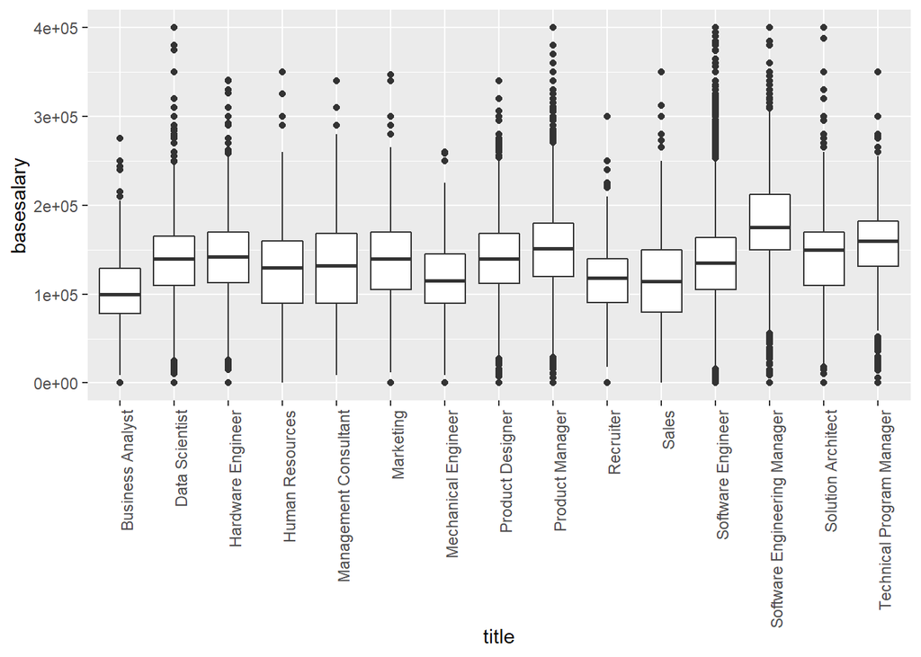

```r
filtered_df %>%
  ggplot(aes(title,basesalary))  + geom_boxplot() +
  theme(axis.text.x = element_text(angle = 90, hjust = 1)) +
  ylim(0,400000)
```

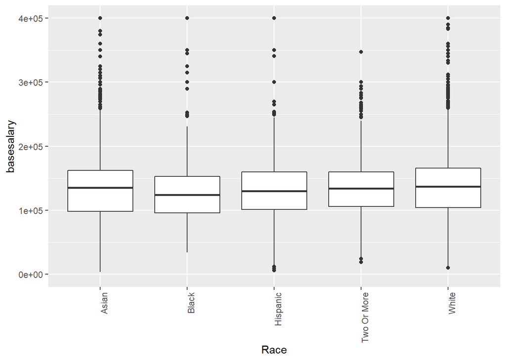

```r
filtered_df %>% filter(!is.na(Race)) %>%
  ggplot(aes(Race,basesalary))  + geom_boxplot() +
  theme(axis.text.x = element_text(angle = 90, hjust = 1)) +
  ylim(0,400000)
```

```r
sum(is.na(filtered_df$Race)) / length(filtered_df$Race)
```

```
## [1] 0.6419814
```

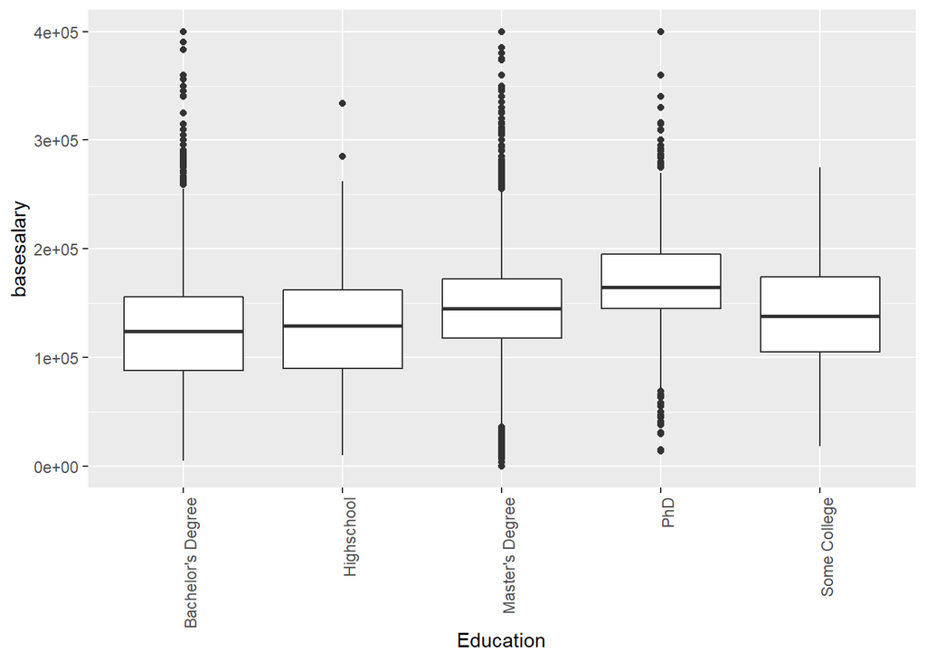

```r
filtered_df %>% filter(!is.na(Education)) %>%
  ggplot(aes(Education,basesalary))  + geom_boxplot() +
  theme(axis.text.x = element_text(angle = 90, hjust = 1)) +
  ylim(0,400000)
```

```r
sum(is.na(filtered_df$Education)) / length(filtered_df$Education)
```

```
## [1] 0.5151815
```

```r
filtered_df$y <- ifelse(filtered_df$basesalary>100000, 1, 0)
table(filtered_df$y)
```

```
##
##     0     1
## 13996 48646
```

```r
df <- filtered_df %>% select(c("company", "title", "location", "yearsofexperience", "yearsatcompany",
'basesalary','gender','cityid','dmaid','Race','Education'))
```

## Final Analysis

### Logistic Regression

```r
df_1 <- filtered_df %>% select(c("title", "yearsofexperience", "yearsatcompany",'gender','cityid','dmaid','Race','Education', 'y')) %>% filter(!is.na(Education) & !is.na(gender) & !is.na(Race))
mod_logistic_whole = glm(y ~ ., data = df_1, family=binomial())
summary(mod_logistic_whole)
```

```
##
## Call:
## glm(formula = y ~ ., family = binomial(), data = df_1)
##
## Deviance Residuals:
##     Min       1Q   Median       3Q      Max
## -3.8414  -0.2398   0.2447   0.4764   2.8765
##
## Coefficients:
##                                     Estimate Std. Error z value Pr(>|z|)
## (Intercept)                       -4.744e+00  1.540e-01 -30.813  < 2e-16 ***
## titleData Scientist                1.756e+00  1.687e-01  10.409  < 2e-16 ***
## titleHardware Engineer             1.305e+00  1.780e-01   7.330 2.31e-13 ***
## titleHuman Resources               1.899e-01  2.606e-01   0.728  0.46634
## titleManagement Consultant         1.341e+00  1.793e-01   7.477 7.60e-14 ***
## titleMarketing                     8.753e-01  2.074e-01   4.221 2.43e-05 ***
## titleMechanical Engineer           1.097e-01  2.017e-01   0.544  0.58671
## titleProduct Designer              1.683e+00  1.861e-01   9.041  < 2e-16 ***
## titleProduct Manager               1.964e+00  1.576e-01  12.466  < 2e-16 ***
## titleRecruiter                    -1.334e-01  2.137e-01  -0.624  0.53243
## titleSales                         2.588e-01  2.207e-01   1.172  0.24109
## titleSoftware Engineer             1.967e+00  1.284e-01  15.322  < 2e-16 ***
## titleSoftware Engineering Manager  2.444e+00  1.874e-01  13.041  < 2e-16 ***
## titleSolution Architect            2.144e+00  2.155e-01   9.950  < 2e-16 ***
## titleTechnical Program Manager     1.783e+00  2.107e-01   8.461  < 2e-16 ***
## yearsofexperience                  2.515e-01  7.253e-03  34.672  < 2e-16 ***
## yearsatcompany                    -1.040e-01  1.033e-02 -10.067  < 2e-16 ***
## genderMale                        -5.588e-02  5.980e-02  -0.935  0.35003
## genderOther                       -3.813e-01  2.994e-01  -1.273  0.20285
## cityid                            -1.794e-05  2.593e-06  -6.919 4.54e-12 ***
## dmaid                              5.586e-03  8.084e-05  69.095  < 2e-16 ***
## RaceBlack                         -1.155e-01  1.141e-01  -1.013  0.31129
## RaceHispanic                       2.529e-02  9.795e-02   0.258  0.79628
## RaceTwo Or More                    3.370e-01  1.200e-01   2.808  0.00499 **
## RaceWhite                          2.951e-01  4.918e-02   6.000 1.98e-09 ***
## EducationHighschool                1.816e-02  1.764e-01   0.103  0.91802
## EducationMaster's Degree           6.269e-01  4.845e-02  12.938  < 2e-16 ***
## EducationPhD                       2.205e+00  1.808e-01  12.197  < 2e-16 ***
## EducationSome College             -2.632e-01  1.752e-01  -1.502  0.13307
## ---
## Signif. codes:  0 '***' 0.001 '**' 0.01 '*' 0.05 '.' 0.1 ' ' 1
##
## (Dispersion parameter for binomial family taken to be 1)
##
##     Null deviance: 24537  on 21590  degrees of freedom
## Residual deviance: 13733  on 21562  degrees of freedom
## AIC: 13791
##
## Number of Fisher Scoring iterations: 6
```

From our full model, we see that all of our covariates provide helpful information with as least one category being significant except gender. We then try a bidirectional step-wise selection procedure to further feature selection.

```r
mod_logistic_step <- step(glm(y ~ 1, data = df_1), ~ title + yearsofexperience + yearsatcompany + gender + cityid + dmaid + Race + Education, direction = "both")
```

```
## Start:  AIC=25440.86
## y ~ 1
##
##                     Df Deviance   AIC
## + dmaid              1   2636.0 15873
## + yearsofexperience  1   3865.6 24138
## + Education          4   3957.1 24650
## + title             14   3981.3 24801
## + cityid             1   4051.0 25150
## + yearsatcompany     1   4053.8 25165
## + Race               4   4097.5 25403
## + gender             2   4102.0 25422
## <none>                   4106.3 25441
##
## Step:  AIC=15872.76
## y ~ dmaid
##
##                     Df Deviance   AIC
## + yearsofexperience  1   2443.2 14234
## + title             14   2535.3 15059
## + Education          4   2584.2 15452
## + yearsatcompany     1   2612.0 15677
## + Race               4   2622.4 15768
## + cityid             1   2626.2 15794
## + gender             2   2633.2 15854
## <none>                   2636.0 15873
## - dmaid              1   4106.3 25441
##
## Step:  AIC=14234.24
## y ~ dmaid + yearsofexperience
##
##                     Df Deviance   AIC
## + title             14   2373.3 13636
## + Education          4   2406.7 13918
## + yearsatcompany     1   2434.1 14156
## + cityid             1   2434.2 14157
## + Race               4   2438.9 14204
## + gender             2   2442.5 14233
## <none>                   2443.2 14234
## - yearsofexperience  1   2636.0 15873
```

[output cut: 72 more lines]

```
##
## Step:  AIC=13126.16
## y ~ dmaid + yearsofexperience + title + Education + Race + yearsatcompany +
##     cityid + gender
##
##                     Df Deviance   AIC
## <none>                   2315.4 13126
## - gender             2   2315.8 13126
## - cityid             1   2321.6 13183
## - yearsatcompany     1   2322.4 13190
## - Race               4   2324.5 13203
## - Education          4   2352.2 13459
## - title             14   2382.7 13717
## - yearsofexperience  1   2446.5 14314
## - dmaid              1   3616.1 22750
```

```r
summary(mod_logistic_step)
```

```
##
## Call:
## glm(formula = y ~ dmaid + yearsofexperience + title + Education +
##     Race + yearsatcompany + cityid + gender, data = df_1)
##
## Deviance Residuals:
##      Min        1Q    Median        3Q       Max
## -1.23406  -0.17568   0.04748   0.18000   1.06349
##
## Coefficients:
##                                     Estimate Std. Error t value Pr(>|t|)
## (Intercept)                       -8.181e-02  1.742e-02  -4.698 2.65e-06 ***
## dmaid                              8.005e-04  7.273e-06 110.061  < 2e-16 ***
## yearsofexperience                  1.706e-02  4.881e-04  34.948  < 2e-16 ***
## titleData Scientist                2.543e-01  1.929e-02  13.185  < 2e-16 ***
## titleHardware Engineer             2.025e-01  1.963e-02  10.317  < 2e-16 ***
## titleHuman Resources               9.695e-02  2.980e-02   3.254 0.001141 **
## titleManagement Consultant         2.164e-01  2.193e-02   9.868  < 2e-16 ***
## titleMarketing                     1.711e-01  2.333e-02   7.331 2.36e-13 ***
## titleMechanical Engineer           4.749e-02  2.580e-02   1.841 0.065700 .
## titleProduct Designer              2.507e-01  2.058e-02  12.180  < 2e-16 ***
## titleProduct Manager               2.622e-01  1.782e-02  14.713  < 2e-16 ***
## titleRecruiter                     3.574e-02  2.742e-02   1.303 0.192432
## titleSales                         8.300e-02  2.714e-02   3.058 0.002232 **
## titleSoftware Engineer             2.653e-01  1.584e-02  16.750  < 2e-16 ***
## titleSoftware Engineering Manager  2.910e-01  1.896e-02  15.348  < 2e-16 ***
## titleSolution Architect            3.128e-01  2.264e-02  13.813  < 2e-16 ***
## titleTechnical Program Manager     2.416e-01  2.047e-02  11.801  < 2e-16 ***
## EducationHighschool                8.544e-03  1.928e-02   0.443 0.657587
## EducationMaster's Degree           7.533e-02  4.910e-03  15.342  < 2e-16 ***
## EducationPhD                       1.501e-01  1.163e-02  12.904  < 2e-16 ***
## EducationSome College             -2.698e-02  1.822e-02  -1.481 0.138662
## RaceBlack                         -1.534e-02  1.325e-02  -1.158 0.246793
## RaceHispanic                       1.812e-02  1.062e-02   1.707 0.087849 .
## RaceTwo Or More                    4.394e-02  1.241e-02   3.540 0.000401 ***
## RaceWhite                          4.380e-02  5.101e-03   8.586  < 2e-16 ***
## yearsatcompany                    -6.505e-03  8.026e-04  -8.105 5.54e-16 ***
## cityid                            -2.249e-06  2.940e-07  -7.648 2.12e-14 ***
## genderMale                        -7.803e-03  6.109e-03  -1.277 0.201476
## genderOther                       -5.672e-02  3.255e-02  -1.743 0.081421 .
## ---
## Signif. codes:  0 '***' 0.001 '**' 0.01 '*' 0.05 '.' 0.1 ' ' 1
##
## (Dispersion parameter for gaussian family taken to be 0.1073816)
##
##     Null deviance: 4106.3  on 21590  degrees of freedom
## Residual deviance: 2315.4  on 21562  degrees of freedom
## AIC: 13126
##
## Number of Fisher Scoring iterations: 2
```

```r
df_2 <- filtered_df %>% select(c("basesalary", "title", "yearsofexperience", "yearsatcompany",'cityid','dmaid','Race','Education', 'y')) %>% filter(!is.na(Education)) %>% filter(!is.na(Race)) %>% filter(basesalary!=0)

df_2 <- df_2 %>% select(c("title", "yearsofexperience", "yearsatcompany",'cityid','dmaid','Race','Education', 'y'))
df_2$y <- as.factor(df_2$y)
dim(df_2)
```

```
## [1] 21681     8
```

Build our final logistic model with the edited dataset.

```r
mod_logistic = glm(y ~ ., data = df_2, family=binomial())
summary(mod_logistic)
```

```
##
## Call:
## glm(formula = y ~ ., family = binomial(), data = df_2)
##
## Deviance Residuals:
##     Min       1Q   Median       3Q      Max
## -3.8335  -0.2442   0.2442   0.4759   2.8707
##
## Coefficients:
##                                     Estimate Std. Error z value Pr(>|z|)
## (Intercept)                       -4.788e+00  1.487e-01 -32.202  < 2e-16 ***
## titleData Scientist                1.754e+00  1.685e-01  10.410  < 2e-16 ***
## titleHardware Engineer             1.305e+00  1.770e-01   7.372 1.68e-13 ***
## titleHuman Resources               1.879e-01  2.591e-01   0.725  0.46840
## titleManagement Consultant         1.338e+00  1.793e-01   7.464 8.41e-14 ***
## titleMarketing                     8.799e-01  2.072e-01   4.247 2.17e-05 ***
## titleMechanical Engineer           9.124e-02  2.009e-01   0.454  0.64965
## titleProduct Designer              1.691e+00  1.857e-01   9.110  < 2e-16 ***
## titleProduct Manager               1.977e+00  1.576e-01  12.544  < 2e-16 ***
## titleRecruiter                    -1.187e-01  2.130e-01  -0.557  0.57733
## titleSales                         2.594e-01  2.207e-01   1.175  0.23996
## titleSoftware Engineer             1.957e+00  1.279e-01  15.300  < 2e-16 ***
## titleSoftware Engineering Manager  2.432e+00  1.867e-01  13.024  < 2e-16 ***
## titleSolution Architect            2.144e+00  2.149e-01   9.977  < 2e-16 ***
## titleTechnical Program Manager     1.784e+00  2.106e-01   8.472  < 2e-16 ***
## yearsofexperience                  2.514e-01  7.223e-03  34.807  < 2e-16 ***
## yearsatcompany                    -1.045e-01  1.031e-02 -10.135  < 2e-16 ***
## cityid                            -1.782e-05  2.588e-06  -6.886 5.75e-12 ***
## dmaid                              5.594e-03  8.050e-05  69.489  < 2e-16 ***
## RaceBlack                         -1.132e-01  1.140e-01  -0.994  0.32037
## RaceHispanic                       3.128e-02  9.781e-02   0.320  0.74914
## RaceTwo Or More                    3.468e-01  1.197e-01   2.898  0.00375 **
## RaceWhite                          2.959e-01  4.907e-02   6.031 1.63e-09 ***
## EducationHighschool                5.985e-03  1.761e-01   0.034  0.97289
## EducationMaster's Degree           6.272e-01  4.836e-02  12.970  < 2e-16 ***
## EducationPhD                       2.196e+00  1.799e-01  12.202  < 2e-16 ***
## EducationSome College             -2.656e-01  1.754e-01  -1.515  0.12990
## ---
## Signif. codes:  0 '***' 0.001 '**' 0.01 '*' 0.05 '.' 0.1 ' ' 1
##
## (Dispersion parameter for binomial family taken to be 1)
##
##     Null deviance: 24646  on 21680  degrees of freedom
## Residual deviance: 13781  on 21654  degrees of freedom
## AIC: 13835
##
## Number of Fisher Scoring iterations: 6
```

Feature selection done, test accuracy next.

```r
set.seed(1)
x <- stratified(df_2, "y", 0.8, keep.rownames = TRUE)
train_set <- x %>% dplyr::select(-rn)
train_index <- as.numeric(x$rn)
test_set <- df_2[-train_index,]
print(dim(train_set))
```

```
## [1] 17345     8
```

```r
print(dim(test_set))
```

```
## [1] 4336    8
```

```r
head(train_set)
```

| title | yearsofexperience | yearsatcompany | cityid | dmaid | Race | Education | y |
| --- | --- | --- | --- | --- | --- | --- | --- |
| Product Manager | 10 | 2 | 10182 | 501 | Hispanic | Bachelor's Degree | 1 |
| Product Manager | 6 | 1 | 7419 | 807 | Black | Master's Degree | 1 |
| Software Engineering Manager | 20 | 5 | 7434 | 807 | Two Or More | Master's Degree | 1 |
| Sales | 10 | 4 | 11527 | 819 | Asian | Master's Degree | 1 |
| Software Engineer | 10 | 0 | 10965 | 635 | Asian | Master's Degree | 1 |
| Product Designer | 8 | 1 | 7419 | 807 | White | Bachelor's Degree | 1 |

```r
head(test_set)
```

|  | title | yearsofexperience | yearsatcompany | cityid | dmaid | Race | Education | y |
| --- | --- | --- | --- | --- | --- | --- | --- | --- |
| 1 | Software Engineer | 5 | 5 | 7472 | 807 | Asian | PhD | 1 |
| 2 | Software Engineer | 3 | 2 | 11521 | 819 | Two Or More | Bachelor's Degree | 1 |
| 12 | Software Engineer | 4 | 1 | 11527 | 819 | Hispanic | Highschool | 1 |
| 15 | Software Engineer | 0 | 0 | 7053 | 753 | Asian | Master's Degree | 1 |
| 20 | Software Engineer | 1 | 0 | 11527 | 819 | Hispanic | Bachelor's Degree | 1 |
| 29 | Software Engineer | 10 | 6 | 7275 | 803 | Asian | Master's Degree | 1 |

```r
mod_logistic_train = glm(y ~ ., data = train_set, family=binomial())
preds_hat <- predict(mod_logistic_train, newdata = test_set, type= "response")
preds <- ifelse(preds_hat>0.5,1,0)
preds <- as.numeric(substring(preds,-1))
confusionMatrix(data = as.factor(preds), reference = as.factor(test_set$y), positive = "1")
```

```
## Confusion Matrix and Statistics
##
##           Reference
## Prediction    0    1
##          0  715  201
##          1  393 3027
##
##                Accuracy : 0.863
##                  95% CI : (0.8524, 0.8731)
##     No Information Rate : 0.7445
##     P-Value [Acc > NIR] : < 2.2e-16
##
##                   Kappa : 0.6182
##
##  Mcnemar's Test P-Value : 4.621e-15
##
##             Sensitivity : 0.9377
##             Specificity : 0.6453
##          Pos Pred Value : 0.8851
##          Neg Pred Value : 0.7806
##              Prevalence : 0.7445
##          Detection Rate : 0.6981
##    Detection Prevalence : 0.7887
##       Balanced Accuracy : 0.7915
##
##        'Positive' Class : 1
##
```

Our logistic regression model yields an overall accuracy of 0.863 with 95% CI (0.8524, 0.8731) and a very small p-value, which indicates that we did an OK job in predicting basesalary >= 100K. However, our sensitivity is 0.9377 and our specificity is 0.6453, giving a balanced accuracy of 0.7915. This means our logistic regression prediction model is making more Type 1 error (False positive) than type 2 errors.

### Data Manipulation for KNN, Decision Tree, and Random Forest

We want to take a look on how many unique values are in our dataset, for categorical feature such as company and feature.

```r
filtered_dataset <- filtered_df %>% filter(!is.na(.))
print(length(unique(filtered_dataset$company)))
```

```
## [1] 1633
```

```r
print(length(unique(filtered_dataset$title)))
```

```
## [1] 15
```

Since there are too many unique company in our dataset, it is better to cluster these companies to reduce the dimensionality of the company feature. Our current approach is to cluster companies based on its size(a.k.a number of time each company appear in the dataset). We re-classify company into 5 classes.

```r
sorted_company <- filtered_dataset %>% count(tolower(company)) %>% arrange(desc(n))
sorted_company
```

| tolower(company) | n |
| --- | --- |
| amazon | 8199 |
| microsoft | 5241 |
| google | 4362 |
| facebook | 3004 |
| apple | 2047 |
| oracle | 1143 |
| salesforce | 1065 |
| intel | 966 |
| ibm | 927 |
| cisco | 923 |

[output cut: 1092 more lines]

```r
filtered_dataset <- filtered_dataset %>% mutate(company = tolower(company))
df <- left_join(filtered_dataset, sorted_company, by = c("company" = "tolower(company)"))
df <- df %>% mutate(size_category  = case_when(
  n <= 10 ~ "<10",
  n > 10 & n <= 50 ~ "10~50",
  n > 50 & n <= 100 ~"50~100",
  n > 100 & n <= 500 ~ "100~500",
  n > 500 ~ "500+"

))
df <- df %>% mutate(employee_num = n) %>% select(-n)
head(df)
```

|  | company | title | totalyearlycompensation | location | yearsofexperience | yearsatcompany | basesalary | stockgrantvalue | bonus | gender | cityid | dmaid | Race | Education | y | size_category | employee_num |
| --- | --- | --- | --- | --- | --- | --- | --- | --- | --- | --- | --- | --- | --- | --- | --- | --- | --- |
| 1 | oracle | Product Manager | 127000 | Redwood City, CA | 1.5 | 1.5 | 107000 | 20000 | 10000 | NA | 7392 | 807 | NA | NA | 1 | 500+ | 1143 |
| 2 | ebay | Software Engineer | 100000 | San Francisco, CA | 5.0 | 3.0 | 0 | 0 | 0 | NA | 7419 | 807 | NA | NA | 0 | 100~500 | 366 |
| 3 | amazon | Product Manager | 310000 | Seattle, WA | 8.0 | 0.0 | 155000 | 0 | 0 | NA | 11527 | 819 | NA | NA | 1 | 500+ | 8199 |
| 4 | apple | Software Engineering Manager | 372000 | Sunnyvale, CA | 7.0 | 5.0 | 157000 | 180000 | 35000 | NA | 7472 | 807 | NA | NA | 1 | 500+ | 2047 |
| 5 | microsoft | Software Engineer | 157000 | Mountain View, CA | 5.0 | 3.0 | 0 | 0 | 0 | NA | 7322 | 807 | NA | NA | 0 | 500+ | 5241 |
| 6 | microsoft | Software Engineer | 208000 | Seattle, WA | 8.5 | 8.5 | 0 | 0 | 0 | NA | 11527 | 819 | NA | NA | 0 | 500+ | 5241 |

The location feature looks a little bit untidy. So we separate it into city, state, country.

```r
location <- df %>%
  count(location) %>%
  arrange(desc(n)) %>%
  mutate(place = location) %>%
  separate(place, sep = ",",  c("city", "state", "country"))
location[is.na(location)] <- "US"
df <- left_join(df, location, by = "location") %>% select(-location)
head(df)
```

|  | company | title | totalyearlycompensation | yearsofexperience | yearsatcompany | basesalary | stockgrantvalue | bonus | gender | cityid | dmaid | Race | Education | y | size_category | employee_num | n | city | state | country |
| --- | --- | --- | --- | --- | --- | --- | --- | --- | --- | --- | --- | --- | --- | --- | --- | --- | --- | --- | --- | --- |
| 1 | oracle | Product Manager | 127000 | 1.5 | 1.5 | 107000 | 20000 | 10000 | NA | 7392 | 807 | NA | NA | 1 | 500+ | 1143 | 459 | Redwood City | CA | US |
| 2 | ebay | Software Engineer | 100000 | 5.0 | 3.0 | 0 | 0 | 0 | NA | 7419 | 807 | NA | NA | 0 | 100~500 | 366 | 6797 | San Francisco | CA | US |
| 3 | amazon | Product Manager | 310000 | 8.0 | 0.0 | 155000 | 0 | 0 | NA | 11527 | 819 | NA | NA | 1 | 500+ | 8199 | 8701 | Seattle | WA | US |
| 4 | apple | Software Engineering Manager | 372000 | 7.0 | 5.0 | 157000 | 180000 | 35000 | NA | 7472 | 807 | NA | NA | 1 | 500+ | 2047 | 2248 | Sunnyvale | CA | US |
| 5 | microsoft | Software Engineer | 157000 | 5.0 | 3.0 | 0 | 0 | 0 | NA | 7322 | 807 | NA | NA | 0 | 500+ | 5241 | 2275 | Mountain View | CA | US |
| 6 | microsoft | Software Engineer | 208000 | 8.5 | 8.5 | 0 | 0 | 0 | NA | 11527 | 819 | NA | NA | 0 | 500+ | 5241 | 8701 | Seattle | WA | US |

After the manipulation we want to see how exactly the distribution of dataset looks like for different locations

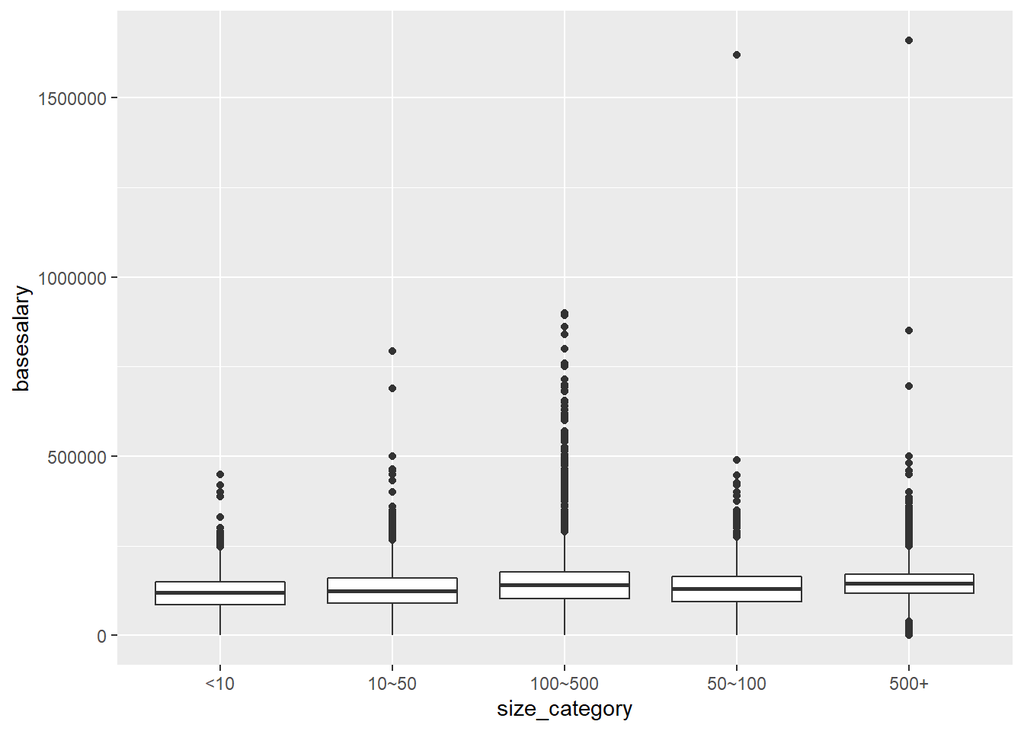

```r
df %>% ggplot(aes(size_category, basesalary)) + geom_boxplot()
```

[figure not shown]

```r
df %>% ggplot(aes(country, basesalary)) + geom_boxplot()
```

We want to take a look on the U.S. data specifically

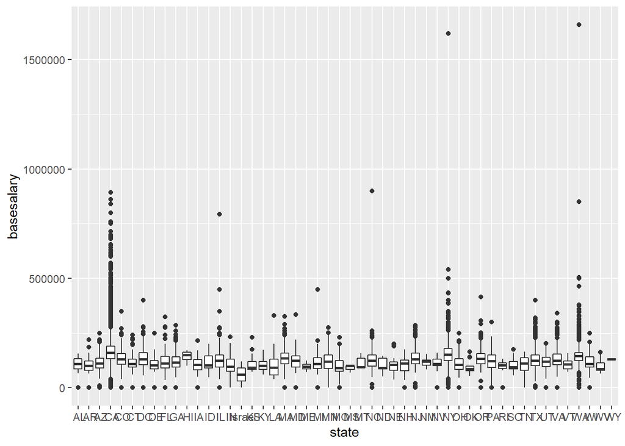

```r
df %>% filter(country == "US") %>% ggplot(aes(state, basesalary)) + geom_boxplot()
```

we want to drop missing value and see how the dataset looks like.

```r
cleaned_df <- drop_na(df)
dim(cleaned_df)
```

```
## [1] 21591    20
```

We also need to factorize our variables.

```r
cleaned_df <- cleaned_df %>% mutate(gender = as.factor(gender), size_category = as.factor(size_category),
                                  state = as.factor(state), country = as.factor(country), y = as.factor(y))
dataset <- cleaned_df %>% select(c("title", "yearsofexperience", "yearsatcompany","gender","cityid","dmaid",
                                  "Race","Education", "y","size_category","state","country"))
sapply(dataset, "class")
```

```
##             title yearsofexperience    yearsatcompany            gender
##          "factor"         "numeric"         "numeric"          "factor"
##            cityid             dmaid              Race         Education
##         "integer"         "integer"          "factor"          "factor"
##                 y     size_category             state           country
##          "factor"          "factor"          "factor"          "factor"
```

Now our dataset looks good and we can get started to build up our model!

### KNN

```r
set.seed(42)
x <- stratified(dataset, "y", 0.8, keep.rownames = TRUE)
train_set <- x %>% dplyr::select(-rn)
train_index <- as.numeric(x$rn)
test_set <- dataset[-train_index,]
print(dim(train_set))
```

```
## [1] 17273    12
```

```r
print(dim(test_set))
```

```
## [1] 4318   12
```

```r
set.seed(42)
knn_fit <- train_set %>% knn3(y~., data = ., k = 12)
knn_hat <- predict(knn_fit, newdata = test_set, type = "class")
knn_p <- f_hat2 <- predict(knn_fit, newdata = test_set, k=12)[,2]
confusionMatrix(data = knn_hat, reference = as.factor(test_set$y), positive = "1")
```

```
## Confusion Matrix and Statistics
##
##           Reference
## Prediction    0    1
##          0  827  161
##          1  276 3054
##
##                Accuracy : 0.8988
##                  95% CI : (0.8894, 0.9076)
##     No Information Rate : 0.7446
##     P-Value [Acc > NIR] : < 2.2e-16
##
##                   Kappa : 0.7245
##
##  Mcnemar's Test P-Value : 4.943e-08
##
##             Sensitivity : 0.9499
##             Specificity : 0.7498
##          Pos Pred Value : 0.9171
##          Neg Pred Value : 0.8370
##              Prevalence : 0.7446
##          Detection Rate : 0.7073
##    Detection Prevalence : 0.7712
##       Balanced Accuracy : 0.8498
##
##        'Positive' Class : 1
##
```

## Decision Tree

We then apply a decision tree to visualize the prediction of the majority class of our outcome (whether one receives >$100k/yr base salary) based within the decision process partitioning based on a combination of variables.

We selected a set of covariates that could potentially be predictive of the outcome variable. After combinatory attempts to construct the tree, three combinations resulted in clear partition of majority class in the outcome variable:

```r
# Create dataset for the trees
dataset_dt <- cleaned_df %>% select(c("title", "yearsofexperience", "yearsatcompany","gender","cityid","dmaid",
                                  "Race","Education", "y","size_category","state","country","employee_num"))
sapply(dataset_dt, class)
```

```
##             title yearsofexperience    yearsatcompany            gender
##          "factor"         "numeric"         "numeric"          "factor"
##            cityid             dmaid              Race         Education
##         "integer"         "integer"          "factor"          "factor"
##                 y     size_category             state           country
##          "factor"          "factor"          "factor"          "factor"
##      employee_num
##         "integer"
```

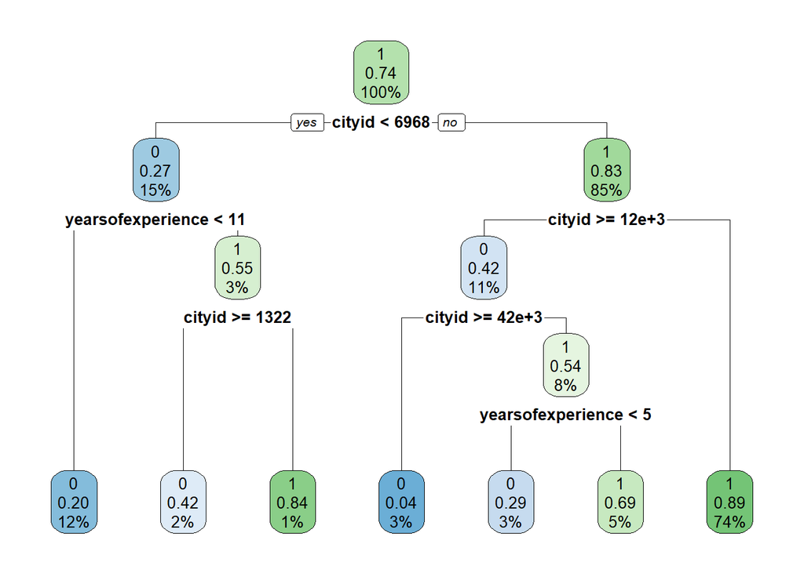

```r
# Decision Tree using cityid (proxy for location), years of experience, and years at company
dt_df1 <- dataset_dt %>% dplyr::select(., y, cityid, yearsofexperience, yearsatcompany)
fit1 <- rpart(as.factor(y) ~ ., data = dt_df1)

rpart.plot(fit1)
```

In the first tree, the outcome is partitioned by years of experience < 11, city id as a proxy for the importance of locations, and years of experience < 5.

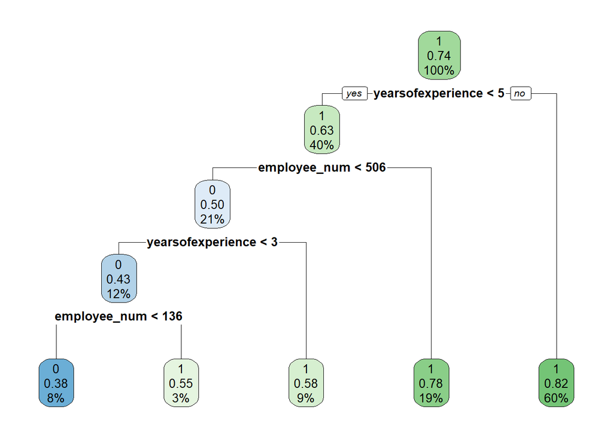

```r
# Next, Decision Tree using years of experience, and employee number
dt_df2 <- dataset_dt %>% dplyr::select(.,y, yearsofexperience, employee_num)
fit2 <- rpart(as.factor(y) ~ ., data = dt_df2)

rpart.plot(fit2)
```

In the second decision tree, if years of experience > 5, we predict the outcome to be >$100k/yr base salary. If not, if employee number of the company is larger than 506, the outcome category is also predicted to be >$100k/yr base salary. The next divisions are made by years of experience > 3 and emplyee number > 136.

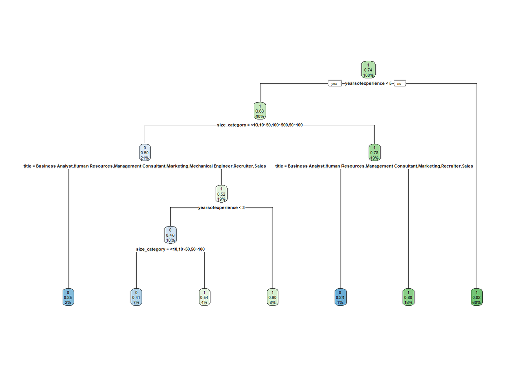

```r
# Thirdly, Decision Tree using title, company size category, and years of experience
dt_df3 <- dataset_dt %>% dplyr::select(.,y, title, size_category, yearsofexperience)
fit3 <- rpart(as.factor(y) ~ ., data = dt_df3)

rpart.plot(fit3)
```

The third tree predicts the outcome by the same cutoffs in years of experience. The rest of the division lies in size category and title.

### Random Forest

We build a random forest model with 3 features for each tree (~ sqrt level)

```r
set.seed(42)
rf_fit <- randomForest(y ~ .-state-country, data = train_set, mtry = 3)
rf_hat <- predict(rf_fit, newdata = test_set, type = "class")
rf_p <- predict(rf_fit, newdata = test_set, type = "prob")[,2]
confusionMatrix(data = rf_hat, reference = as.factor(test_set$y), positive = "1")
```

```
## Confusion Matrix and Statistics
##
##           Reference
## Prediction    0    1
##          0  870  162
##          1  233 3053
##
##                Accuracy : 0.9085
##                  95% CI : (0.8995, 0.917)
##     No Information Rate : 0.7446
##     P-Value [Acc > NIR] : < 2.2e-16
##
##                   Kappa : 0.7543
##
##  Mcnemar's Test P-Value : 0.0004282
##
##             Sensitivity : 0.9496
##             Specificity : 0.7888
##          Pos Pred Value : 0.9291
##          Neg Pred Value : 0.8430
##              Prevalence : 0.7446
##          Detection Rate : 0.7070
##    Detection Prevalence : 0.7610
##       Balanced Accuracy : 0.8692
##
##        'Positive' Class : 1
##
```

Now, check the feature importance

```r
rf_im <- importance(rf_fit)
as.matrix(rf_im[order(-rf_im[,1]),])
```

```
##                         [,1]
## dmaid             2013.06633
## cityid            1501.71226
## yearsofexperience  853.07254
## title              539.38443
## size_category      398.53391
## yearsatcompany     331.52472
## Race               280.51223
## Education          209.93064
## gender              84.32126
```

### Visualization

Here, we do a visualization using tSNE.

First, to reduce computational burden, we randomly sample 5000 points for visualization. At the same time, since `cityid` and `dmaid` are two strongest factors, we only keep `dmaid` to avoid overfitting.

```r
data_sample0 <- dataset[sample(1:nrow(dataset), size = 5000),]
data_sample <- data_sample0[ , -which(colnames(data_sample0) %in% c("cityid"))]
```

```r
# Obtain the value of 2-D tSNE embedding
tsne_out <- Rtsne(
 data_sample,
 dims = 2,
 pca = TRUE,
 perplexity = 100,
 check_duplicates = FALSE
)
```

Now, let’s see the pattern of different labels

```r
rd_rs <- as.data.frame(tsne_out$Y)
rd_rs$Class<- data_sample$y
# first obtain the color
length(unique(rd_rs$Class))
```

```
## [1] 2
```

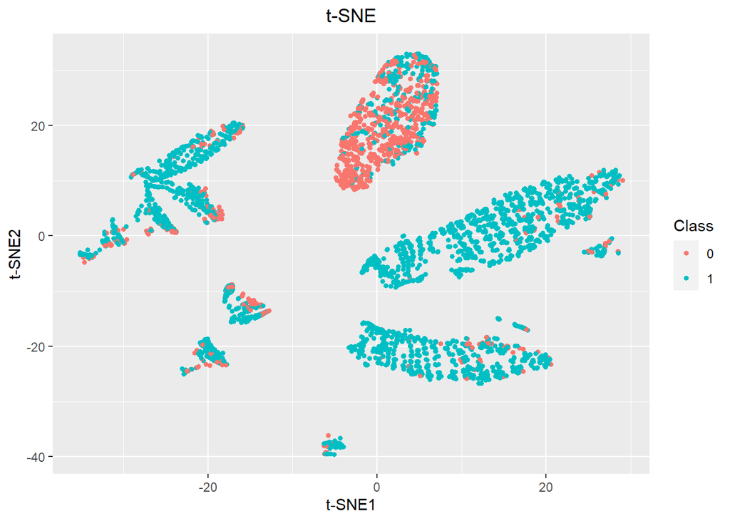

```r
mainPalette <- rainbow(9)
ggplot(rd_rs, aes(x=V1, y=V2, color=Class)) +
  geom_point(size=1.25) +
  labs(title = "t-SNE",
       x = "t-SNE1",
       y = "t-SNE2") +
  theme(plot.title = element_text(hjust = 0.5))
```

Let’s see the pattern of the strongest factor `dmaid`

```r
rd_rs <- as.data.frame(tsne_out$Y)
rd_rs$Class<- data_sample$dmaid
# first obtain the color
length(unique(rd_rs$Class))
```

```
## [1] 88
```

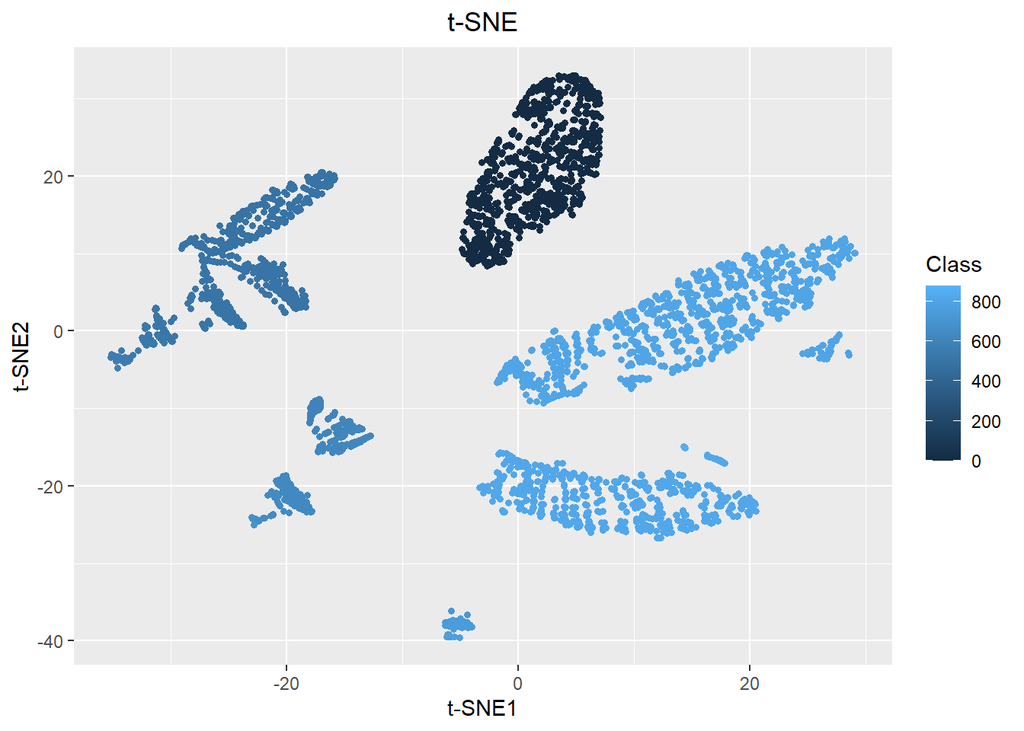

```r
mainPalette <- rainbow(9)
ggplot(rd_rs, aes(x=V1, y=V2, color=Class)) +
  geom_point(size=1.25) +
  labs(title = "t-SNE",
       x = "t-SNE1",
       y = "t-SNE2") +
  theme(plot.title = element_text(hjust = 0.5))
```

### Linear Regression

We also wanted to fit the Dataset into a linear regression model so that we will be able to make predictions on base salary given information about a person’s relevant features. So in this analysis, we explored the performance of different feature engineering and encoding methods, as well as the prediction performance of several linear regression model. We will choose the best model to make our base salary predictor in the next section.

#### Explore Dataset

```r
dataframe = read.csv("Levels_Fyi_Salary_Data.csv")
head(dataframe)
```

|  | timestamp | company | level | title | totalyearlycompensation | location | yearsofexperience | yearsatcompany | tag | basesalary | stockgrantvalue | bonus | gender | otherdetails | cityid | dmaid | rowNumber | Masters_Degree | Bachelors_Degree | Doctorate_Degree | Highschool | Some_College | Race_Asian | Race_White | Race_Two_Or_More | Race_Black | Race_Hispanic | Race | Education |
| --- | --- | --- | --- | --- | --- | --- | --- | --- | --- | --- | --- | --- | --- | --- | --- | --- | --- | --- | --- | --- | --- | --- | --- | --- | --- | --- | --- | --- | --- |
| 1 | 6/7/2017 11:33:27 | Oracle | L3 | Product Manager | 127000 | Redwood City, CA | 1.5 | 1.5 | NA | 107000 | 20000 | 10000 | NA | NA | 7392 | 807 | 1 | 0 | 0 | 0 | 0 | 0 | 0 | 0 | 0 | 0 | 0 | NA | NA |
| 2 | 6/10/2017 17:11:29 | eBay | SE 2 | Software Engineer | 100000 | San Francisco, CA | 5.0 | 3.0 | NA | 0 | 0 | 0 | NA | NA | 7419 | 807 | 2 | 0 | 0 | 0 | 0 | 0 | 0 | 0 | 0 | 0 | 0 | NA | NA |
| 3 | 6/11/2017 14:53:57 | Amazon | L7 | Product Manager | 310000 | Seattle, WA | 8.0 | 0.0 | NA | 155000 | 0 | 0 | NA | NA | 11527 | 819 | 3 | 0 | 0 | 0 | 0 | 0 | 0 | 0 | 0 | 0 | 0 | NA | NA |
| 4 | 6/17/2017 0:23:14 | Apple | M1 | Software Engineering Manager | 372000 | Sunnyvale, CA | 7.0 | 5.0 | NA | 157000 | 180000 | 35000 | NA | NA | 7472 | 807 | 7 | 0 | 0 | 0 | 0 | 0 | 0 | 0 | 0 | 0 | 0 | NA | NA |
| 5 | 6/20/2017 10:58:51 | Microsoft | 60 | Software Engineer | 157000 | Mountain View, CA | 5.0 | 3.0 | NA | 0 | 0 | 0 | NA | NA | 7322 | 807 | 9 | 0 | 0 | 0 | 0 | 0 | 0 | 0 | 0 | 0 | 0 | NA | NA |
| 6 | 6/21/2017 17:27:47 | Microsoft | 63 | Software Engineer | 208000 | Seattle, WA | 8.5 | 8.5 | NA | 0 | 0 | 0 | NA | NA | 11527 | 819 | 11 | 0 | 0 | 0 | 0 | 0 | 0 | 0 | 0 | 0 | 0 | NA | NA |

```r
filtered_df <- dataframe %>%
  select(c("company", "title", "totalyearlycompensation", "location", "yearsofexperience", "yearsatcompany",
'basesalary','stockgrantvalue','bonus','gender','cityid','dmaid','Race','Education')) %>%
  mutate(company = as.factor(company), title <- as.factor(title), Race <- as.factor(Race), Education <- as.factor(Education)) %>%
  filter(!is.na(Education) & !is.na(gender) & !is.na(Race))

head(filtered_df)
```

|  | company | title | totalyearlycompensation | location | yearsofexperience | yearsatcompany | basesalary | stockgrantvalue | bonus | gender | cityid | dmaid | Race | Education | title <- as.factor(title) | Race <- as.factor(Race) | Education <- as.factor(Education) |
| --- | --- | --- | --- | --- | --- | --- | --- | --- | --- | --- | --- | --- | --- | --- | --- | --- | --- |
| 1 | Google | Software Engineer | 400000 | Sunnyvale, CA | 5 | 5 | 210000 | 145000 | 45000 | Male | 7472 | 807 | Asian | PhD | Software Engineer | Asian | PhD |
| 2 | Microsoft | Software Engineer | 136000 | Redmond, WA | 3 | 2 | 124000 | 1000 | 11000 | Male | 11521 | 819 | Two Or More | Bachelor's Degree | Software Engineer | Two Or More | Bachelor's Degree |
| 3 | Google | Software Engineer | 337000 | San Bruno, CA | 6 | 6 | 177000 | 125000 | 36000 | Male | 7413 | 807 | Asian | Bachelor's Degree | Software Engineer | Asian | Bachelor's Degree |
| 4 | Microsoft | Software Engineer | 222000 | Seattle, WA | 4 | 4 | 164000 | 38000 | 20000 | Male | 11527 | 819 | Asian | Master's Degree | Software Engineer | Asian | Master's Degree |
| 5 | Blend | Software Engineer | 187000 | San Francisco, CA | 5 | 0 | 165000 | 22000 | 0 | Male | 7419 | 807 | White | Bachelor's Degree | Software Engineer | White | Bachelor's Degree |
| 6 | Amazon | Software Engineer | 310000 | Seattle, WA | 15 | 3 | 160000 | 150000 | 0 | Male | 11527 | 819 | Asian | Bachelor's Degree | Software Engineer | Asian | Bachelor's Degree |

Since the location in this data frame is encoded as City, State, Country (except for locations in the US, where it is encoded as City, State), we would like to split this into 3 separate features and take a look into the distribution of countries.

```r
location <- filtered_df %>%
  count(location) %>%
  arrange(desc(n)) %>%
  mutate(place = location) %>%
  separate(place, sep = ",",  c("city", "state", "country"))
location[is.na(location)] = "US"
```

Join the location table with our original dataset.

```r
joined_df <- filtered_df %>%
  left_join(location, by = "location")

head(joined_df)
```

|  | company | title | totalyearlycompensation | location | yearsofexperience | yearsatcompany | basesalary | stockgrantvalue | bonus | gender | cityid | dmaid | Race | Education | title <- as.factor(title) | Race <- as.factor(Race) | Education <- as.factor(Education) | n | city | state | country |
| --- | --- | --- | --- | --- | --- | --- | --- | --- | --- | --- | --- | --- | --- | --- | --- | --- | --- | --- | --- | --- | --- |
| 1 | Google | Software Engineer | 400000 | Sunnyvale, CA | 5 | 5 | 210000 | 145000 | 45000 | Male | 7472 | 807 | Asian | PhD | Software Engineer | Asian | PhD | 610 | Sunnyvale | CA | US |
| 2 | Microsoft | Software Engineer | 136000 | Redmond, WA | 3 | 2 | 124000 | 1000 | 11000 | Male | 11521 | 819 | Two Or More | Bachelor's Degree | Software Engineer | Two Or More | Bachelor's Degree | 754 | Redmond | WA | US |
| 3 | Google | Software Engineer | 337000 | San Bruno, CA | 6 | 6 | 177000 | 125000 | 36000 | Male | 7413 | 807 | Asian | Bachelor's Degree | Software Engineer | Asian | Bachelor's Degree | 31 | San Bruno | CA | US |
| 4 | Microsoft | Software Engineer | 222000 | Seattle, WA | 4 | 4 | 164000 | 38000 | 20000 | Male | 11527 | 819 | Asian | Master's Degree | Software Engineer | Asian | Master's Degree | 2516 | Seattle | WA | US |
| 5 | Blend | Software Engineer | 187000 | San Francisco, CA | 5 | 0 | 165000 | 22000 | 0 | Male | 7419 | 807 | White | Bachelor's Degree | Software Engineer | White | Bachelor's Degree | 1759 | San Francisco | CA | US |
| 6 | Amazon | Software Engineer | 310000 | Seattle, WA | 15 | 3 | 160000 | 150000 | 0 | Male | 11527 | 819 | Asian | Bachelor's Degree | Software Engineer | Asian | Bachelor's Degree | 2516 | Seattle | WA | US |

After ploting the base salary for different countries, we can see that there is a large discrapencies between each countries.

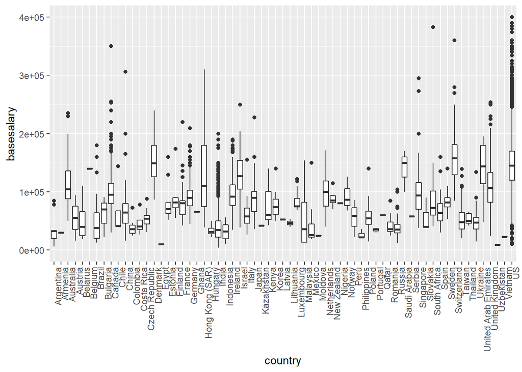

```r
joined_df %>%
  ggplot(aes(country,basesalary))  +
  geom_boxplot() +
  theme(axis.text.x = element_text(angle = 90, hjust = 1)) +
  ylim(0,400000)
```

If we list the number of data we have for each countries, we can also see that the dataset is very imbalanced – the majoriety of data comes from the US, where as other countries only contribute a very small amount of data, this can be a major problem for machine learning models, since there may not be enough data for the model to learn the representation for other countries properly. Therefore, we decided to filter only data from the US, and train the linear regression model as a base salary predictor for the US.

```r
joined_df %>%
  count(country) %>%
  arrange(desc(n))
```

| country | n |
| --- | --- |
| US | 16962 |
| India | 1527 |
| Canada | 778 |
| United Kingdom | 532 |
| Germany | 269 |
| Taiwan | 189 |
| Singapore | 149 |
| Ireland | 140 |
| Israel | 124 |
| Russia | 116 |

[output cut: 55 more lines]

```r
us_df <- joined_df %>%
  filter(country == "US")

head(us_df)
```

|  | company | title | totalyearlycompensation | location | yearsofexperience | yearsatcompany | basesalary | stockgrantvalue | bonus | gender | cityid | dmaid | Race | Education | title <- as.factor(title) | Race <- as.factor(Race) | Education <- as.factor(Education) | n | city | state | country |
| --- | --- | --- | --- | --- | --- | --- | --- | --- | --- | --- | --- | --- | --- | --- | --- | --- | --- | --- | --- | --- | --- |
| 1 | Google | Software Engineer | 400000 | Sunnyvale, CA | 5 | 5 | 210000 | 145000 | 45000 | Male | 7472 | 807 | Asian | PhD | Software Engineer | Asian | PhD | 610 | Sunnyvale | CA | US |
| 2 | Microsoft | Software Engineer | 136000 | Redmond, WA | 3 | 2 | 124000 | 1000 | 11000 | Male | 11521 | 819 | Two Or More | Bachelor's Degree | Software Engineer | Two Or More | Bachelor's Degree | 754 | Redmond | WA | US |
| 3 | Google | Software Engineer | 337000 | San Bruno, CA | 6 | 6 | 177000 | 125000 | 36000 | Male | 7413 | 807 | Asian | Bachelor's Degree | Software Engineer | Asian | Bachelor's Degree | 31 | San Bruno | CA | US |
| 4 | Microsoft | Software Engineer | 222000 | Seattle, WA | 4 | 4 | 164000 | 38000 | 20000 | Male | 11527 | 819 | Asian | Master's Degree | Software Engineer | Asian | Master's Degree | 2516 | Seattle | WA | US |
| 5 | Blend | Software Engineer | 187000 | San Francisco, CA | 5 | 0 | 165000 | 22000 | 0 | Male | 7419 | 807 | White | Bachelor's Degree | Software Engineer | White | Bachelor's Degree | 1759 | San Francisco | CA | US |
| 6 | Amazon | Software Engineer | 310000 | Seattle, WA | 15 | 3 | 160000 | 150000 | 0 | Male | 11527 | 819 | Asian | Bachelor's Degree | Software Engineer | Asian | Bachelor's Degree | 2516 | Seattle | WA | US |

#### Feature Engineering

Next we would like to proceed to the feature engineering stage. Since we are building the linear regression model to use it as the base salary predictor for our Shiny App, we can only include features that we want users to input for their salary prediction. This means that we cannot use feature such as `dmaid` in the model since we don’t know what this feature represent. So after looking at our EDA plots, we decided to choose 6 features: `title`, `company`, `yearsatcompany`, `yearsofexperience`, `Education`, and `Race` as our features.

Considering the ease of calculation for our Shiny App Predictor, we also decided to use a categorical encoding for each feature instead of one-hot encoding, even though empirically one-hot encoding may yield better results.

To do the feature engineering for `title`, we plot the average base salary for each title again. We can see that there is a clear difference in average base salary for different title.

```r
us_df %>%
  drop_na() %>%
  mutate(company = str_to_title(company)) %>%
  select(c("company", "title", "location", "yearsofexperience", "yearsatcompany",
'basesalary','gender','cityid','dmaid','Race','Education'))
```

| company | title | location | yearsofexperience | yearsatcompany | basesalary | gender | cityid | dmaid | Race | Education |
| --- | --- | --- | --- | --- | --- | --- | --- | --- | --- | --- |
| Google | Software Engineer | Sunnyvale, CA | 5 | 5 | 210000 | Male | 7472 | 807 | Asian | PhD |
| Microsoft | Software Engineer | Redmond, WA | 3 | 2 | 124000 | Male | 11521 | 819 | Two Or More | Bachelor's Degree |
| Google | Software Engineer | San Bruno, CA | 6 | 6 | 177000 | Male | 7413 | 807 | Asian | Bachelor's Degree |
| Microsoft | Software Engineer | Seattle, WA | 4 | 4 | 164000 | Male | 11527 | 819 | Asian | Master's Degree |
| Blend | Software Engineer | San Francisco, CA | 5 | 0 | 165000 | Male | 7419 | 807 | White | Bachelor's Degree |
| Amazon | Software Engineer | Seattle, WA | 15 | 3 | 160000 | Male | 11527 | 819 | Asian | Bachelor's Degree |
| Chevron | Software Engineer | Houston, TX | 3 | 3 | 103000 | Male | 11109 | 618 | Hispanic | Bachelor's Degree |
| Amazon | Software Engineering Manager | Seattle, WA | 19 | 7 | 160000 | Male | 11527 | 819 | Asian | Bachelor's Degree |
| Square | Software Engineer | San Francisco, CA | 5 | 1 | 140000 | Male | 7419 | 807 | Black | Some College |
| Amazon | Software Engineer | Seattle, WA | 4 | 1 | 150000 | Male | 11527 | 819 | Hispanic | Highschool |

[output cut: 9990 more lines]

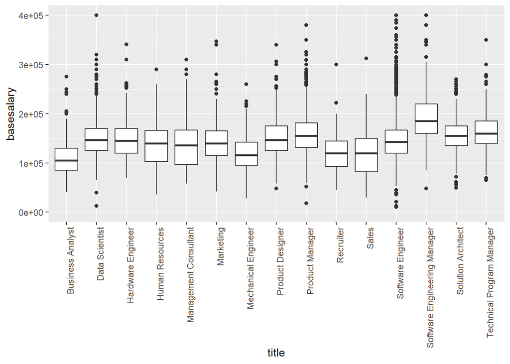

```r
us_df %>%
  ggplot(aes(title,basesalary))  +
  geom_boxplot() +
  theme(axis.text.x = element_text(angle = 90, hjust = 1)) +
  ylim(0,400000)
```

In order to make sure that our title encoding can capture this pattern of differences, we decided to first encode each title category as their average base salary, and later we would also normalize this encoding value to range between [0, 1].

```r
title_mean <- us_df %>%
  group_by(title) %>%
  summarise(title_encode = mean(basesalary)/10000) %>%
  arrange(desc(title_encode))

title_mean
```

| title | title_encode |
| --- | --- |
| Software Engineering Manager | 19.78780 |
| Technical Program Manager | 16.32298 |
| Product Manager | 16.00375 |
| Solution Architect | 15.55000 |
| Data Scientist | 15.16764 |
| Product Designer | 15.01081 |
| Hardware Engineer | 14.75823 |
| Software Engineer | 14.73918 |
| Marketing | 14.28452 |
| Management Consultant | 14.25571 |

[output cut: 5 more lines]

We repeat the same process for the other 5 featues.

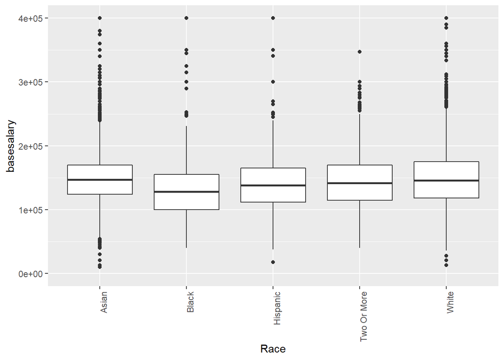

```r
us_df %>%
  filter(!is.na(Race)) %>%
  ggplot(aes(Race,basesalary))  +
  geom_boxplot() +
  theme(axis.text.x = element_text(angle = 90, hjust = 1)) +
  ylim(0,400000)
```

```r
race_mean <- us_df %>%
  group_by(Race) %>%
  summarise(race_encode = mean(basesalary)/10000) %>%
  arrange(desc(race_encode))

race_mean
```

| Race | race_encode |
| --- | --- |
| White | 15.09778 |
| Asian | 15.08383 |
| Two Or More | 14.67048 |
| Hispanic | 14.18877 |
| Black | 13.53832 |

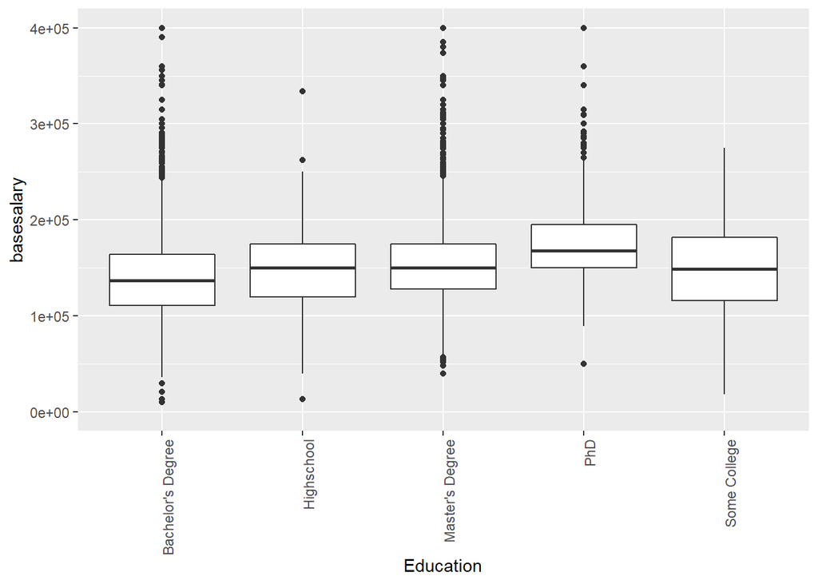

```r
us_df %>%
  filter(!is.na(Education)) %>%
  ggplot(aes(Education,basesalary))  +
  geom_boxplot() +
  theme(axis.text.x = element_text(angle = 90, hjust = 1)) +
  ylim(0,400000)
```

```r
education_mean <- us_df %>%
  group_by(Education) %>%
  summarise(education_encode = mean(basesalary)/10000) %>%
  arrange(desc(education_encode))

education_mean
```

| Education | education_encode |
| --- | --- |
| PhD | 17.73386 |
| Master's Degree | 15.53269 |
| Highschool | 15.33523 |
| Some College | 15.19539 |
| Bachelor's Degree | 14.17034 |

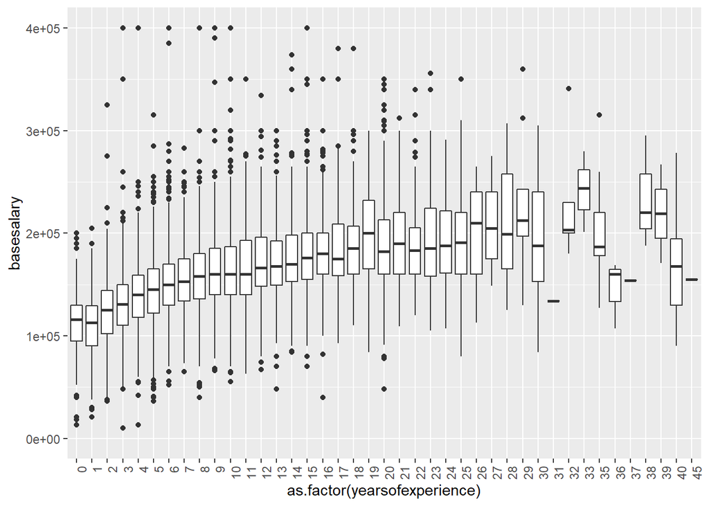

```r
us_df %>%
  filter(!is.na(yearsofexperience)) %>%
  ggplot(aes(as.factor(yearsofexperience),basesalary))  +
  geom_boxplot() +
  theme(axis.text.x = element_text(angle = 90, hjust = 1)) +
  ylim(0,400000)
```

```r
experience_mean <- us_df %>%
  group_by(yearsofexperience) %>%
  summarise(experience_encode = mean(basesalary)/10000) %>%
  arrange(desc(experience_encode))

experience_mean
```

| yearsofexperience | experience_encode |
| --- | --- |
| 33 | 24.16667 |
| 38 | 23.43333 |
| 32 | 23.08000 |
| 29 | 22.70000 |
| 39 | 21.90000 |
| 19 | 21.17143 |
| 28 | 21.10667 |
| 27 | 20.96471 |
| 21 | 20.86571 |
| 22 | 20.44638 |

[output cut: 31 more lines]

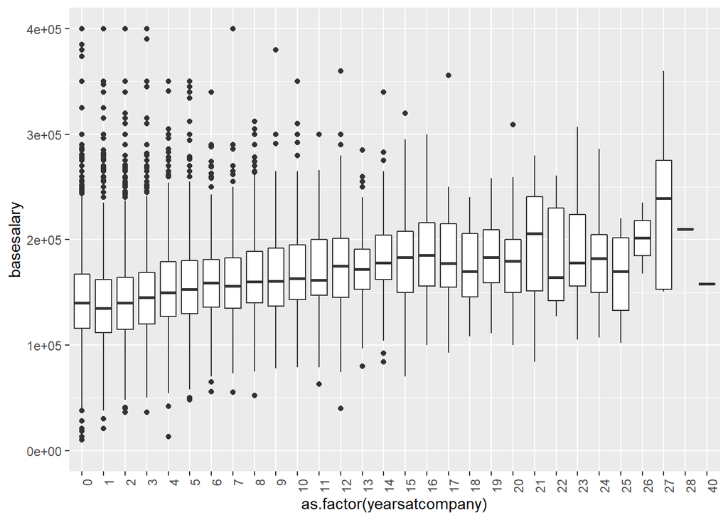

```r
us_df %>%
  filter(!is.na(yearsatcompany)) %>%
  ggplot(aes(as.factor(yearsatcompany),basesalary))  +
  geom_boxplot() +
  theme(axis.text.x = element_text(angle = 90, hjust = 1)) +
  ylim(0,400000)
```

```r
yearatcompany_mean <- us_df %>%
  group_by(yearsatcompany) %>%
  summarise(yearatcompany_encode = mean(basesalary)/10000) %>%
  arrange(desc(yearatcompany_encode))

yearatcompany_mean
```

| yearsatcompany | yearatcompany_encode |
| --- | --- |
| 27 | 23.56000 |
| 28 | 21.00000 |
| 26 | 20.15000 |
| 23 | 19.93846 |
| 21 | 19.86000 |
| 14 | 18.84531 |
| 16 | 18.73846 |
| 17 | 18.65000 |
| 22 | 18.54545 |
| 19 | 18.47500 |

[output cut: 20 more lines]

For the feature `company`, we know that this dataset includes data from 1633 distinct companies, so we think it would probably be better it we convert `company` into new new feature with less levels. To do this, we first take a look into how the `company` feature distribution looks like.

```r
company <- us_df %>%
  count(company) %>%
  arrange(desc(n))

head(company)
```

|  | company | n |
| --- | --- | --- |
| 1 | Amazon | 2079 |
| 2 | Microsoft | 1290 |
| 3 | Google | 1099 |
| 4 | Facebook | 867 |
| 5 | Apple | 563 |
| 6 | Oracle | 307 |

We also plot this distribution in a histrogram.

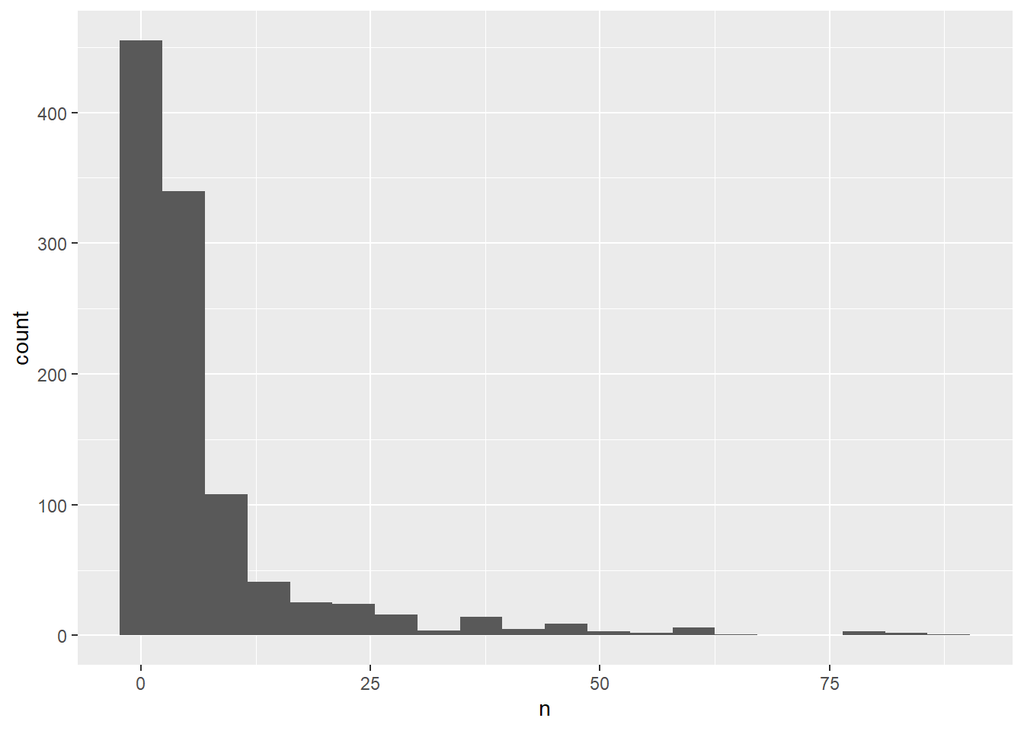

```r
company %>%
  filter(n <= 100) %>%
  ggplot(aes(n)) +
  geom_histogram(bins = 20)
```

```r
company_size <- company %>%
  mutate(company_size = case_when(
    n <= 3 ~ "1",
    n <= 10 ~ "3 - 10",
    n <= 50 ~ "11 - 50",
    n <= 100 ~ "51 - 100",
    n <= 500 ~ "101 - 500",
    TRUE ~ ">500"
  ))
```

```r
us_df <- us_df %>%
  left_join(company_size, by = "company")

head(us_df)
```

|  | company | title | totalyearlycompensation | location | yearsofexperience | yearsatcompany | basesalary | stockgrantvalue | bonus | gender | cityid | dmaid | Race | Education | title <- as.factor(title) | Race <- as.factor(Race) | Education <- as.factor(Education) | n.x | city | state | country | n.y | company_size |
| --- | --- | --- | --- | --- | --- | --- | --- | --- | --- | --- | --- | --- | --- | --- | --- | --- | --- | --- | --- | --- | --- | --- | --- |
| 1 | Google | Software Engineer | 400000 | Sunnyvale, CA | 5 | 5 | 210000 | 145000 | 45000 | Male | 7472 | 807 | Asian | PhD | Software Engineer | Asian | PhD | 610 | Sunnyvale | CA | US | 1099 | >500 |
| 2 | Microsoft | Software Engineer | 136000 | Redmond, WA | 3 | 2 | 124000 | 1000 | 11000 | Male | 11521 | 819 | Two Or More | Bachelor's Degree | Software Engineer | Two Or More | Bachelor's Degree | 754 | Redmond | WA | US | 1290 | >500 |
| 3 | Google | Software Engineer | 337000 | San Bruno, CA | 6 | 6 | 177000 | 125000 | 36000 | Male | 7413 | 807 | Asian | Bachelor's Degree | Software Engineer | Asian | Bachelor's Degree | 31 | San Bruno | CA | US | 1099 | >500 |
| 4 | Microsoft | Software Engineer | 222000 | Seattle, WA | 4 | 4 | 164000 | 38000 | 20000 | Male | 11527 | 819 | Asian | Master's Degree | Software Engineer | Asian | Master's Degree | 2516 | Seattle | WA | US | 1290 | >500 |
| 5 | Blend | Software Engineer | 187000 | San Francisco, CA | 5 | 0 | 165000 | 22000 | 0 | Male | 7419 | 807 | White | Bachelor's Degree | Software Engineer | White | Bachelor's Degree | 1759 | San Francisco | CA | US | 4 | 3 - 10 |
| 6 | Amazon | Software Engineer | 310000 | Seattle, WA | 15 | 3 | 160000 | 150000 | 0 | Male | 11527 | 819 | Asian | Bachelor's Degree | Software Engineer | Asian | Bachelor's Degree | 2516 | Seattle | WA | US | 2079 | >500 |

We also repeat the same process for feature engineering.

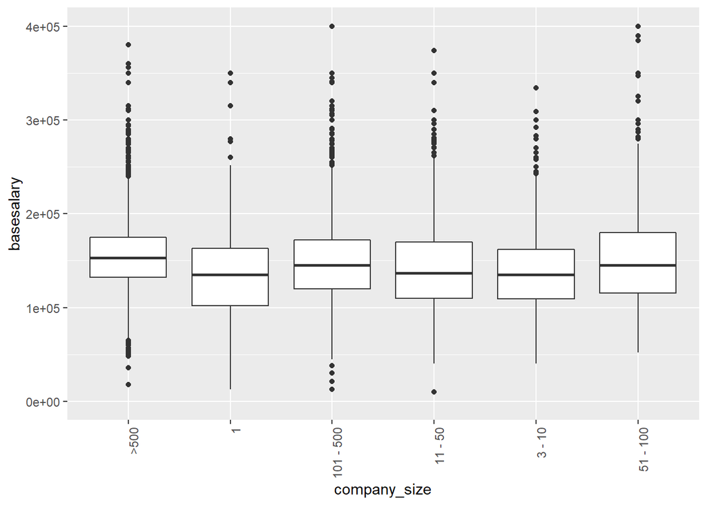

```r
us_df %>%
  filter(!is.na(company_size)) %>%
  ggplot(aes(company_size,basesalary))  +
  geom_boxplot() +
  theme(axis.text.x = element_text(angle = 90, hjust = 1)) +
  ylim(0,400000)
```

```r
company_mean <- us_df %>%
  group_by(company_size) %>%
  summarise(company_encode = mean(basesalary)/10000) %>%
  arrange(desc(company_encode))

company_mean
```

| company_size | company_encode |
| --- | --- |
| 51 - 100 | 17.22039 |
| >500 | 15.60990 |
| 101 - 500 | 14.92588 |
| 11 - 50 | 14.23479 |
| 3 - 10 | 13.76469 |
| 1 | 13.55260 |

To create the final dataframe for our model, we need to join all encoded feature together and normalize these feature to range between [0, 1] using the `min_max_norm` function.

```r
min_max_norm <- function(x) {
    (x - min(x)) / (max(x) - min(x))
  }
```

```r
lm_us_df<- us_df %>%
  left_join(company_mean, by = "company_size") %>%
  left_join(title_mean, by = "title") %>%
  left_join(education_mean, by = "Education") %>%
  left_join(race_mean, by = "Race") %>%
  left_join(experience_mean, by = "yearsofexperience") %>%
  left_join(yearatcompany_mean, by = "yearsatcompany") %>%
  mutate(company = min_max_norm(company_encode), title = min_max_norm(title_encode), education = min_max_norm(education_encode), race = min_max_norm(race_encode), experience = min_max_norm(experience_encode), yearsatcompany = min_max_norm(yearatcompany_encode)) %>%
  select(basesalary, company, title, education, race, experience, yearsatcompany)

head(lm_us_df)
```

|  | basesalary | company | title | education | race | experience | yearsatcompany |
| --- | --- | --- | --- | --- | --- | --- | --- |
| 1 | 210000 | 0.56091088 | 0.4178631 | 1.0000000 | 0.9910542 | 0.2622556 | 0.21409549 |
| 2 | 124000 | 0.56091088 | 0.4178631 | 0.0000000 | 0.7259940 | 0.1561210 | 0.03267062 |
| 3 | 177000 | 0.56091088 | 0.4178631 | 0.0000000 | 0.9910542 | 0.3319421 | 0.22504788 |
| 4 | 164000 | 0.56091088 | 0.4178631 | 0.3823049 | 0.9910542 | 0.2106055 | 0.16634609 |
| 5 | 165000 | 0.05782566 | 0.4178631 | 0.0000000 | 1.0000000 | 0.2622556 | 0.04769924 |
| 6 | 160000 | 0.56091088 | 0.4178631 | 0.0000000 | 0.9910542 | 0.5676737 | 0.08653295 |

#### Saving cleaned data and encoded features

We save the cleaned dataframe into a .csv file and also save all the encoding data so that we can use them for reference when we later calculate the predicted base salary in our Shiny App Predictor.

```r
write.csv(x=us_df, file="project/clean_us_salary_data.csv", row.names = FALSE)
```

```r
company_encode <- company_size %>%
  left_join(company_mean, by = "company_size") %>%
  mutate(x = company, y = min_max_norm(company_encode)) %>%
  select(x, y, company_size)

write.csv(x=company_encode, file="project/company_encode.csv", row.names = FALSE)

head(company_encode)
```

|  | x | y | company_size |
| --- | --- | --- | --- |
| 1 | Amazon | 0.5609109 | >500 |
| 2 | Microsoft | 0.5609109 | >500 |
| 3 | Google | 0.5609109 | >500 |
| 4 | Facebook | 0.5609109 | >500 |
| 5 | Apple | 0.5609109 | >500 |
| 6 | Oracle | 0.3744156 | 101 - 500 |

```r
education_encode <- education_mean %>%
  mutate(x = Education, y = min_max_norm(education_encode)) %>%
  select(x, y)

write.csv(x=education_encode, file="project/education_encode.csv", row.names = FALSE)

head(education_encode)
```

| x | y |
| --- | --- |
| PhD | 1.0000000 |
| Master's Degree | 0.3823049 |
| Highschool | 0.3268951 |
| Some College | 0.2876522 |
| Bachelor's Degree | 0.0000000 |

```r
title_encode <- title_mean %>%
  mutate(x = title, y = min_max_norm(title_encode)) %>%
  select(x, y)

write.csv(x=title_encode, file="project/title_encode.csv", row.names = FALSE)

head(title_encode)
```

| x | y |
| --- | --- |
| Software Engineering Manager | 1.0000000 |
| Technical Program Manager | 0.6004853 |
| Product Manager | 0.5636758 |
| Solution Architect | 0.5113559 |
| Data Scientist | 0.4672677 |
| Product Designer | 0.4491840 |

```r
yearsatcompany_encode <- yearatcompany_mean %>%
  mutate(x = yearsatcompany, y = min_max_norm(yearatcompany_encode)) %>%
  select(x, y)

write.csv(x=yearsatcompany_encode, file="project/yearsatcompany_encode.csv", row.names = FALSE)

head(yearsatcompany_encode)
```

| x | y |
| --- | --- |
| 27 | 1.0000000 |
| 28 | 0.7311936 |
| 26 | 0.6419415 |
| 23 | 0.6197294 |
| 21 | 0.6114908 |
| 14 | 0.5049460 |

```r
race_encode <- race_mean %>%
  mutate(x = Race, y = min_max_norm(race_encode)) %>%
  select(x, y)

write.csv(x=race_encode, file="project/race_encode.csv", row.names = FALSE)

head(race_encode)
```

| x | y |
| --- | --- |
| White | 1.0000000 |
| Asian | 0.9910542 |
| Two Or More | 0.7259940 |
| Hispanic | 0.4170973 |
| Black | 0.0000000 |

```r
experience_encode <- experience_mean %>%
  mutate(x = yearsofexperience, y = min_max_norm(experience_encode)) %>%
  select(x, y)

write.csv(x=experience_encode, file="project/experience_encode.csv", row.names = FALSE)

head(experience_encode)
```

| x | y |
| --- | --- |
| 33 | 1.0000000 |
| 38 | 0.9440917 |
| 32 | 0.9171540 |
| 29 | 0.8881834 |
| 39 | 0.8271925 |
| 19 | 0.7716472 |

#### Training the Linear Regression model

To train our linear regression model, we first need to split the dataset into training and testing.

```r
set.seed(1)
idx <- sample.int(n = nrow(lm_us_df), size = floor(0.8 * nrow(lm_us_df)), replace = FALSE)

train <- lm_us_df[idx, ]
test <- lm_us_df[-idx, ]

dim(train)
```

```
## [1] 13569     7
```

```r
dim(test)
```

```
## [1] 3393    7
```

Fit the training dataset into the linear regression model.

```r
lm1 <- lm(basesalary ~ ., data = train)
summary(lm1)
```

```
##
## Call:
## lm(formula = basesalary ~ ., data = train)
##
## Residuals:
##     Min      1Q  Median      3Q     Max
## -136537  -22387   -2887   17936  706237
##
## Coefficients:
##                Estimate Std. Error t value Pr(>|t|)
## (Intercept)       69439       1756  39.543  < 2e-16 ***
## company           31005       1332  23.281  < 2e-16 ***
## title             46921       2199  21.340  < 2e-16 ***
## education         21241       1340  15.847  < 2e-16 ***
## race               8973       1501   5.976 2.34e-09 ***
## experience       125164       2032  61.598  < 2e-16 ***
## yearsatcompany   -30720       3576  -8.589  < 2e-16 ***
## ---
## Signif. codes:  0 '***' 0.001 '**' 0.01 '*' 0.05 '.' 0.1 ' ' 1
##
## Residual standard error: 39170 on 13562 degrees of freedom
## Multiple R-squared:  0.3474, Adjusted R-squared:  0.3471
## F-statistic:  1203 on 6 and 13562 DF,  p-value: < 2.2e-16
```

We can see that all the features are significant, this suggests that they are all important and contribute to the final prediction of base salary. So we now save these coefficient for our base salary predictor.

```r
lm_coef <- summary(lm1)$coefficients
lm_coef_df <- data.frame(coef = rownames(lm_coef), value = lm_coef[, 1], std = lm_coef[, 2], lower = lm_coef[, 1] - lm_coef[, 2], upper = lm_coef[, 1] + lm_coef[, 2])
write.csv(lm_coef_df, file = "project/lm_coef.csv", row.names = FALSE)
```

To evaluate model performance, we choose to calculate its RMSE.

```r
RMSE <- function(true_ratings, predicted_ratings){
    sqrt(mean((true_ratings - predicted_ratings)^2))
}
```

The RMSE for the test dataset prediction is relatively large, however, considering the noise that naturally exists in this dataset, where people with the exact same features is likely to have different base salary, a large testing RMSE doesn’t necessarily suggest that our model is performing bad, and we would need further analysis to fairly evaluate our model performance.

```r
lm_pred <- predict(lm1, newdata = test)
lm_rmse <- RMSE(lm_pred, test$basesalary)
lm_rmse
```

```
## [1] 44100.67
```

By comparing our model prediction and the actual base salary in the testing dataset, we can see that while not accurate, our model is able to capture the general trend of base salary level. This means that the prediction of out model can at least provide some reference for a person’s potential base salary based on their input.

```r
lm_pred[1:10]
```

```
##        1       11       12       17       23       25       26       33
## 162817.7 123619.4 151725.9 169328.8 190601.6 163993.0 173833.8 205034.7
##       35       37
## 153926.6 134367.7
```

```r
test$basesalary[1:10]
```

```
##  [1] 210000 112000 114000 153000 215000 160000 210000 150000 180000 165000
```

#### Optimizing Model Performance - One-hot Encoding and Regularization

To better evaluate our previous model performance, we also want to explore whether we can optimize the previous simple Linear Regression model through one-hot encoding and regularization. To do this, we first need to prepare the one-hot encoded dataset.

```r
library(caret)

df_one_hot <- us_df %>%
  select(title, yearsofexperience, yearsatcompany, basesalary, Education, company_size)

dmy <- dummyVars(" ~ .", data = df_one_hot)
df_one_hot <- data.frame(predict(dmy, newdata = df_one_hot))
str(df_one_hot)
```

```
## 'data.frame':    16962 obs. of  29 variables:
##  $ titleBusiness.Analyst            : num  0 0 0 0 0 0 0 0 0 0 ...
##  $ titleData.Scientist              : num  0 0 0 0 0 0 0 0 0 0 ...
##  $ titleHardware.Engineer           : num  0 0 0 0 0 0 0 0 0 0 ...
##  $ titleHuman.Resources             : num  0 0 0 0 0 0 0 0 0 0 ...
##  $ titleManagement.Consultant       : num  0 0 0 0 0 0 0 0 0 0 ...
##  $ titleMarketing                   : num  0 0 0 0 0 0 0 0 0 0 ...
##  $ titleMechanical.Engineer         : num  0 0 0 0 0 0 0 0 0 0 ...
##  $ titleProduct.Designer            : num  0 0 0 0 0 0 0 0 0 0 ...
##  $ titleProduct.Manager             : num  0 0 0 0 0 0 0 0 0 0 ...
##  $ titleRecruiter                   : num  0 0 0 0 0 0 0 0 0 0 ...
##  $ titleSales                       : num  0 0 0 0 0 0 0 0 0 0 ...
##  $ titleSoftware.Engineer           : num  1 1 1 1 1 1 1 0 1 1 ...
##  $ titleSoftware.Engineering.Manager: num  0 0 0 0 0 0 0 1 0 0 ...
##  $ titleSolution.Architect          : num  0 0 0 0 0 0 0 0 0 0 ...
##  $ titleTechnical.Program.Manager   : num  0 0 0 0 0 0 0 0 0 0 ...
##  $ yearsofexperience                : num  5 3 6 4 5 15 3 19 5 4 ...
##  $ yearsatcompany                   : num  5 2 6 4 0 3 3 7 1 1 ...
##  $ basesalary                       : num  210000 124000 177000 164000 165000 160000 103000 160000 140000 150000 ...
##  $ EducationBachelor.s.Degree       : num  0 1 1 0 1 1 1 1 0 0 ...
##  $ EducationHighschool              : num  0 0 0 0 0 0 0 0 0 1 ...
##  $ EducationMaster.s.Degree         : num  0 0 0 1 0 0 0 0 0 0 ...
##  $ EducationPhD                     : num  1 0 0 0 0 0 0 0 0 0 ...
##  $ EducationSome.College            : num  0 0 0 0 0 0 0 0 1 0 ...
##  $ company_size.500                 : num  1 1 1 1 0 1 0 1 0 1 ...
##  $ company_size1                    : num  0 0 0 0 0 0 0 0 0 0 ...
##  $ company_size101...500            : num  0 0 0 0 0 0 0 0 0 0 ...
##  $ company_size11...50              : num  0 0 0 0 0 0 1 0 1 0 ...
##  $ company_size3...10               : num  0 0 0 0 1 0 0 0 0 0 ...
##  $ company_size51...100             : num  0 0 0 0 0 0 0 0 0 0 ...
```

Split training and testing dataset.

```r
train_one_hot <- df_one_hot[idx, ]
test_one_hot <- df_one_hot[-idx, ]

dim(train_one_hot)
```

```
## [1] 13569    29
```

```r
dim(test_one_hot)
```

```
## [1] 3393   29
```

Fit a linear regression model using the one-hot encoded dataset.

```r
lm2 <- lm(basesalary ~ ., data = train_one_hot)
summary(lm2)
```

```
##
## Call:
## lm(formula = basesalary ~ ., data = train_one_hot)
##
## Residuals:
##     Min      1Q  Median      3Q     Max
## -171030  -21585   -3034   17785  695204
##
## Coefficients: (3 not defined because of singularities)
##                                    Estimate Std. Error t value Pr(>|t|)
## (Intercept)                       124059.55    3549.04  34.956  < 2e-16 ***
## titleBusiness.Analyst             -20200.94    3041.00  -6.643 3.19e-11 ***
## titleData.Scientist                13214.21    2572.28   5.137 2.83e-07 ***
## titleHardware.Engineer               350.77    2569.78   0.136   0.8914
## titleHuman.Resources              -18110.40    4043.71  -4.479 7.57e-06 ***
## titleManagement.Consultant          4746.77    2986.12   1.590   0.1119
## titleMarketing                     -5503.65    3079.53  -1.787   0.0739 .
## titleMechanical.Engineer          -15489.55    3477.12  -4.455 8.47e-06 ***
## titleProduct.Designer               7267.66    2694.45   2.697   0.0070 **
## titleProduct.Manager               12528.27    2268.87   5.522 3.42e-08 ***
## titleRecruiter                    -22051.29    3616.88  -6.097 1.11e-09 ***
## titleSales                        -21751.18    4014.88  -5.418 6.14e-08 ***
## titleSoftware.Engineer             12781.29    1970.06   6.488 9.01e-11 ***
## titleSoftware.Engineering.Manager  28996.51    2453.97  11.816  < 2e-16 ***
## titleSolution.Architect            -3142.63    3183.30  -0.987   0.3236
## titleTechnical.Program.Manager           NA         NA      NA       NA
## yearsofexperience                   4344.42      71.59  60.682  < 2e-16 ***
## yearsatcompany                     -1384.22     117.45 -11.785  < 2e-16 ***
## EducationBachelor.s.Degree          5581.59    2664.75   2.095   0.0362 *
## EducationHighschool                 6319.71    4138.04   1.527   0.1267
## EducationMaster.s.Degree           12344.46    2669.45   4.624 3.79e-06 ***
## EducationPhD                       35833.74    3078.69  11.639  < 2e-16 ***
## EducationSome.College                    NA         NA      NA       NA
## company_size.500                  -16416.31    1439.02 -11.408  < 2e-16 ***
## company_size1                     -33656.74    1893.08 -17.779  < 2e-16 ***
## company_size101...500             -22943.69    1507.73 -15.217  < 2e-16 ***
## company_size11...50               -26394.88    1512.60 -17.450  < 2e-16 ***
## company_size3...10                -31404.97    1687.68 -18.608  < 2e-16 ***
## company_size51...100                     NA         NA      NA       NA
## ---
## Signif. codes:  0 '***' 0.001 '**' 0.01 '*' 0.05 '.' 0.1 ' ' 1
##
## Residual standard error: 39360 on 13543 degrees of freedom
## Multiple R-squared:  0.342,  Adjusted R-squared:  0.3407
## F-statistic: 281.5 on 25 and 13543 DF,  p-value: < 2.2e-16
```

Evaluting model performance using RMSE on testing dataset. The RMSE is slightly lower than our previous linear regression model, which suggests that one-hot encoding do yield better results. However, since the difference is pretty small, we would still use the weight from our previous model for the ease of calculation.

```r
lm2_pred <- predict(lm2, newdata = test_one_hot)
lm_rmse <- RMSE(lm2_pred, test_one_hot$basesalary)
lm_rmse
```

```
## [1] 43922.65
```

```r
library(glmnet)
x = as.matrix(subset(train_one_hot, select=-c(basesalary)))
y_train = train_one_hot$basesalary
x_test = as.matrix(subset(test_one_hot, select=-c(basesalary)))
y_test = train_one_hot$basesalary

ridge_reg = glmnet(x, y_train, alpha = 1, family = 'gaussian', lambda = 0.8)
ridge_reg
```

```
##
## Call:  glmnet(x = x, y = y_train, family = "gaussian", alpha = 1, lambda = 0.8)
##
##   Df %Dev Lambda
## 1 28 34.2    0.8
```

```r
pred <- predict(ridge_reg, newx = x_test)[, 1]
rmse_ridge <- RMSE(pred, y_test)
rmse_ridge
```

```
## [1] 56397
```

Overall, we think our first simple linear regression gives a reasonably good prediction on base salary, so we decided to use its weight to build our final salary predictor shiny app

### Shiny APP

We implemented 4 main features in our Shiny App, which are embedded in 4 seperate tabs.

#### Estimator

User can input their information for each of the 5 features in the drop-down bar, and our salary estimator will return a table of salary estimation as well as the confidence interval for each of the 15 titles.

#### Geo Map

User can either view the base salary distribution across different states in the United States, or choose to filter certain feature level and view the corresponding base salary distribution. However, there are missing value for certain states for specific feature levels.

#### Boxplot

User can view the boxplot of base salary distribution for each of the 6 features

#### Salary distribution plot

User can select a base salary upper bound, and view the distribution of salary.